# Convergence monitoring

Federico M. Stefanini, Nedka D. Nikiforova, Chiara Litardi, Eleonora Peruffo and Massimiliano Mascherini

2020-03-05 Index:

The evaluation of convergence is important not only for determining the dynamic of member states in the EU but also as a support to policy makers.

The R package *convergEU* is a suite of functions to download, clean and analyze some convergence features.

In this document, the package *convergEU* is described and the main functionalities illustrated.

# 1 Datasets on EU member states

Two types of sources are considered: data produced by Eurofound, available without and active Internet connection, and Eurostat data that can be downloaded on the fly, upon necessity from this package.

## 1.1 Locally accessible datasets

Some datasets are accessible from package *convergEU* using the R function *data()*, for example :

```r
library(convergEU)
data("emp_20_64")
head(emp_20_64)
```

Alternatively, a dataframe obtained by reshaping raw data into a time by countries table is also available and typically more usefull:

```r
data("emp_20_64_MS",package = "convergEU")
head(emp_20_64_MS)
```

Eurofound datasets are locally available within the *convergEU* package, see:

```r
data(package = "convergEU")
```

A description of the above data is available by the R help, for example:

```r
help(emp_20_64_MS)
```

Eurofond local data are considered below:

```r
require(convergEU)
data(dbEurofound)
head(dbEurofound)
```

```
#> # A tibble: 6 x 17
#>    time geo   geo_label sex   lifesatisf health goodhealth_p trustlocal volunt
#>   <dbl> <chr> <chr>     <chr>      <dbl>  <dbl>        <dbl>      <dbl>  <dbl>
#> 1  1960 AD    Andorra   Fema…         NA     NA           NA         NA     NA
#> 2  1960 AD    Andorra   Males         NA     NA           NA         NA     NA
#> 3  1960 AD    Andorra   Total         NA     NA           NA         NA     NA
#> 4  1960 AL    Albania   Fema…         NA     NA           NA         NA     NA
#> 5  1960 AL    Albania   Males         NA     NA           NA         NA     NA
#> 6  1960 AL    Albania   Total         NA     NA           NA         NA     NA
#> # … with 8 more variables: volunt_p <dbl>, caring_h <dbl>, socialexc_i <dbl>,
#> #   JQIskill_i <dbl>, JQIenviron_i <dbl>, JQIintensity_i <dbl>,
#> #   JQItime_i <dbl>, exposdiscr_p <dbl>
```

where variable names are:

```r
names(dbEurofound)
```

```
#>  [1] "time"           "geo"            "geo_label"      "sex"
#>  [5] "lifesatisf"     "health"         "goodhealth_p"   "trustlocal"
#>  [9] "volunt"         "volunt_p"       "caring_h"       "socialexc_i"
#> [13] "JQIskill_i"     "JQIenviron_i"   "JQIintensity_i" "JQItime_i"
#> [17] "exposdiscr_p"
```

and time ranges in the interval:

```r
c(min(dbEurofound$time), max(dbEurofound$time))
```

```
#> [1] 1960 2017
```

and the dataset is not complete in such a time range for all considered countries.

Further details on Eurofound dataset are available as follows (metainformation):

```r
data(dbEUF2018meta)
print(dbEUF2018meta,n=20,width=100)
```

```
#> # A tibble: 13 x 10
#>    DIMENSION  SUBDIMENSION  INDICATOR    Code_in_database Official_code    Unit
#>    <chr>      <chr>         <chr>        <chr>            <chr>            <chr>
#>  1 Quality o… Life satisfa… Mean life s… lifesatisf       y16_q4           --
#>  2 Quality o… Health        Mean health… health           y16_q48          --
#>  3 Quality o… Health        Percentage … goodhealth_p     y16_q48          %
#>  4 Quality o… Quality of s… Mean level … trustlocal       y16_q35f         --
#>  5 Quality o… Quality of s… Level of in… volunt           y16_q29a         --
#>  6 Quality o… Quality of s… Percentage … volunt_p         y16_q29a         %
#>  7 Quality o… Quality of s… Hours per w… caring_h         y16_q43a         hours
#>  8 Quality o… Quality of s… Social Excl… socialexc_i      y16_socexindex   index
#>  9 Working c… Working cond… JQI_Skills … JQIskill_i       wq_slim -  JQI … index
#> 10 Working c… Working cond… JQI_Physica… JQIenviron_i     envsec_slim - J… index
#> 11 Working c… Working cond… JQI_Intensi… JQIintensity_i   intens_slim - J… index
#> 12 Working c… Working cond… JQI_Working… JQItime_i        wlb_slim - JQI … index
```

[output cut: 16 more lines]

**NOTE: within convergeEU package, Eurofound data are statically stored**. Please update this package to have the most recent version of Eurofound data.

The first step of an analysis is data preparation. This amounts to choose a time interval, an indicator and a set of countries (MS, Member States), for example:

```r
convergEU_glb()$EU12$memberStates$codeMS
```

```
#>  [1] "BE" "DK" "FR" "DE" "EL" "IE" "IT" "LU" "NL" "PT" "ES" "UK"
```

thus, selecting “lifesatisf” from the column “Code_in_database”

```r
myTB <- extract_indicator_EUF(
    indicator_code = "lifesatisf", #Code_in_database
    fromTime=2003,
    toTime=2016,
    gender= c("Total","Females","Males")[2],
    countries= convergEU_glb()$EU12$memberStates$codeMS
    )

myTB
```

```
#> $res
#> # A tibble: 4 x 14
#>    time sex       BE    DE    DK    EL    ES    FR    IE    IT    LU    NL    PT
#>   <dbl> <chr>  <dbl> <dbl> <dbl> <dbl> <dbl> <dbl> <dbl> <dbl> <dbl> <dbl> <dbl>
#> 1  2003 Femal…  7.38  7.48  8.37  6.75  7.43  6.97  7.89  7.12  7.77  7.54  5.86
#> 2  2007 Femal…  7.49  7.17  8.51  6.55  7.14  7.34  7.66  6.54  7.87  7.90  6.09
#> 3  2011 Femal…  7.47  7.27  8.30  6.13  7.51  7.17  7.41  6.86  7.72  7.74  6.72
#> 4  2016 Femal…  7.27  7.28  8.33  5.30  6.97  7.24  7.66  6.56  7.96  7.74  6.79
#> # … with 1 more variable: UK <dbl>
#>
#> $msg
#> NULL
#>
#> $err
#> NULL
```

If missing values are present, then imputation is required, as described in the next sections.

Another illustrative example follows.

```r
print(dbEUF2018meta,n=20,width=100)
```

```
#> # A tibble: 13 x 10
#>    DIMENSION  SUBDIMENSION  INDICATOR    Code_in_database Official_code    Unit
#>    <chr>      <chr>         <chr>        <chr>            <chr>            <chr>
#>  1 Quality o… Life satisfa… Mean life s… lifesatisf       y16_q4           --
#>  2 Quality o… Health        Mean health… health           y16_q48          --
#>  3 Quality o… Health        Percentage … goodhealth_p     y16_q48          %
#>  4 Quality o… Quality of s… Mean level … trustlocal       y16_q35f         --
#>  5 Quality o… Quality of s… Level of in… volunt           y16_q29a         --
#>  6 Quality o… Quality of s… Percentage … volunt_p         y16_q29a         %
#>  7 Quality o… Quality of s… Hours per w… caring_h         y16_q43a         hours
#>  8 Quality o… Quality of s… Social Excl… socialexc_i      y16_socexindex   index
#>  9 Working c… Working cond… JQI_Skills … JQIskill_i       wq_slim -  JQI … index
#> 10 Working c… Working cond… JQI_Physica… JQIenviron_i     envsec_slim - J… index
#> 11 Working c… Working cond… JQI_Intensi… JQIintensity_i   intens_slim - J… index
#> 12 Working c… Working cond… JQI_Working… JQItime_i        wlb_slim - JQI … index
```

[output cut: 16 more lines]

```r
names(convergEU_glb())
```

```
#>  [1] "EUcodes"         "Eurozone"        "EA"              "EU12"
#>  [5] "EU15"            "EU19"            "EU25"            "EU27_2007"
#>  [9] "EU27_2019"       "EU27_2020"       "EU27"            "EU28"
#> [13] "geoRefEUF"       "metaEUStat"      "tmpl_out"        "paralintags"
#> [17] "rounDigits"      "epsilonV"        "scoreBoaTB"      "labels_clusters"
```

```r
myTB <- extract_indicator_EUF(
    indicator_code = "JQIintensity_i", #Code_in_database
    fromTime= 1965,
    toTime=2016,
    gender= c("Total","Females","Males")[1],
    countries= convergEU_glb()$EU27_2020$memberStates$codeMS
    )

print(myTB$res,n=35,width=250)
```

```
#> # A tibble: 5 x 29
#>    time sex      AT    BE    BG    CY    CZ    DE    DK    EE    EL    ES    FI
#>   <dbl> <chr> <dbl> <dbl> <dbl> <dbl> <dbl> <dbl> <dbl> <dbl> <dbl> <dbl> <dbl>
#> 1  1995 Total  48.8  33.2  NA    NA    NA    40.8  39.0  NA    40.9  34.2  47.1
#> 2  2000 Total  42.9  37.3  43.7  53.4  42.6  40.9  37.6  38.2  43.5  36.2  46.7
#> 3  2005 Total  47.6  42.8  33.8  50.7  45.8  46.9  47.9  41.7  50.5  41.2  49.6
#> 4  2010 Total  42.1  40.2  31.2  52.5  41.9  44.9  39.1  41.9  48.6  38.0  45.9
#> 5  2015 Total  42.4  41.5  34.6  57.2  36.7  40.2  45.0  38.7  49.3  46.5  41.1
#>      FR    HR    HU    IE    IT    LT    LU    LV    MT    NL    PL    PT    RO
#>   <dbl> <dbl> <dbl> <dbl> <dbl> <dbl> <dbl> <dbl> <dbl> <dbl> <dbl> <dbl> <dbl>
#> 1  38.4  NA    NA    39.0  34.1  NA    31.4  NA    NA    41.8  NA    36.2  NA
#> 2  39.5  NA    42.1  42.2  39.7  29.9  37.6  32.8  50.0  41.3  40.9  31.8  47.8
#> 3  40.5  31.6  47.2  36.9  41.9  37.3  40.6  34.3  48.4  40.3  35.7  40.1  45.9
#> 4  43.0  39.5  48.7  47.0  40.8  33.2  40.8  31.9  44.0  38.5  31.4  31.6  43.3
#> 5  42.7  38.4  44.7  42.8  38.1  37.8  42.4  31.5  44.8  38.7  35.0  36.8  54.2
#>      SE    SI    SK
#>   <dbl> <dbl> <dbl>
#> 1  43.3  NA    NA
#> 2  47.9  29.5  41.6
#> 3  48.1  49.2  39.6
#> 4  45.9  48.2  37.6
#> 5  46.1  43.0  35.9
```

Imputation must take place before doing any analysis:

```r
myTBinp <- impute_dataset(myTB$res, timeName = "time",
                          countries=convergEU_glb()$EU27_2020$memberStates$codeMS,
                          tailMiss = c("cut", "constant")[2],
                          headMiss = c("cut", "constant")[2])
print(myTBinp$res,n=35,width=250)
```

```
#> # A tibble: 5 x 29
#>    time sex      AT    BE    BG    CY    CZ    DE    DK    EE    EL    ES    FI
#>   <dbl> <chr> <dbl> <dbl> <dbl> <dbl> <dbl> <dbl> <dbl> <dbl> <dbl> <dbl> <dbl>
#> 1  1995 Total  48.8  33.2  43.7  53.4  42.6  40.8  39.0  38.2  40.9  34.2  47.1
#> 2  2000 Total  42.9  37.3  43.7  53.4  42.6  40.9  37.6  38.2  43.5  36.2  46.7
#> 3  2005 Total  47.6  42.8  33.8  50.7  45.8  46.9  47.9  41.7  50.5  41.2  49.6
#> 4  2010 Total  42.1  40.2  31.2  52.5  41.9  44.9  39.1  41.9  48.6  38.0  45.9
#> 5  2015 Total  42.4  41.5  34.6  57.2  36.7  40.2  45.0  38.7  49.3  46.5  41.1
#>      FR    HR    HU    IE    IT    LT    LU    LV    MT    NL    PL    PT    RO
#>   <dbl> <dbl> <dbl> <dbl> <dbl> <dbl> <dbl> <dbl> <dbl> <dbl> <dbl> <dbl> <dbl>
#> 1  38.4  31.6  42.1  39.0  34.1  29.9  31.4  32.8  50.0  41.8  40.9  36.2  47.8
#> 2  39.5  31.6  42.1  42.2  39.7  29.9  37.6  32.8  50.0  41.3  40.9  31.8  47.8
#> 3  40.5  31.6  47.2  36.9  41.9  37.3  40.6  34.3  48.4  40.3  35.7  40.1  45.9
#> 4  43.0  39.5  48.7  47.0  40.8  33.2  40.8  31.9  44.0  38.5  31.4  31.6  43.3
#> 5  42.7  38.4  44.7  42.8  38.1  37.8  42.4  31.5  44.8  38.7  35.0  36.8  54.2
#>      SE    SI    SK
#>   <dbl> <dbl> <dbl>
#> 1  43.3  29.5  41.6
#> 2  47.9  29.5  41.6
#> 3  48.1  49.2  39.6
#> 4  45.9  48.2  37.6
#> 5  46.1  43.0  35.9
```

## 1.2 Metaresults and missing values check

Several functions in *convergEU* package return a list with metainformation, that is three components: *res, msg, err*. The first list component, *res*, is the actual result, if computed. The second component, *msg* is a message decorating the computed result, possibly a warning. The third component, *err*, is an error message or a list of errors when a result is not computed. Below this behaviour is illustrated for function *check_data*.

The structure of the standard dataset is a time by countries rectangular table. All variables are quantitative. The following function check for such features:

```r
check_data(emp_20_64_MS)
```

```
#> $res
#> [1] TRUE
#>
#> $msg
#> NULL
#>
#> $err
#> NULL
```

where the list component *res* is TRUE, that is all cheks are passed.

In case of qualitative variable or missing data checks fail, for example if time is qualitative:

```r
tmp <-  emp_20_64_MS
tmp <-  mutate(tmp, time=factor(emp_20_64_MS$time))
check_data(tmp)
```

```
#> $res
#> NULL
#>
#> $msg
#> NULL
#>
#> $err
#> [1] "Error: qualitative variables  in the dataframe."
```

the *err* component explains what went wrong.

Similar errors are signaled if the dataset is not complete:

```r
tmp <-  emp_20_64_MS
tmp[3:6,1]<- NA
check_data(tmp)
```

```
#> $res
#> NULL
#>
#> $msg
#> NULL
#>
#> $err
#> [1] "Error: one or more missing values in the dataframe."
```

## 1.3 Imputation for artificially generated missing values in the Eurofound database

Let’s consider the following indicator from the Eurofound database:

```r
myTB <- extract_indicator_EUF(
    indicator_code = "exposdiscr_p", #Code_in_database
    fromTime=1966,
    toTime=2016,
    gender= c("Total","Females","Males")[1],
    countries= convergEU_glb()$EU12$memberStates$codeMS
    )
```

where missing value are absent

```r
sapply(myTB$res,function(vx)sum(is.na(vx)))
```

```
#> time  sex   BE   DE   DK   EL   ES   FR   IE   IT   LU   NL   PT   UK
#>    0    0    0    0    0    0    0    0    0    0    0    0    0    0
```

thus we introduce some missing values and take further years for testing purposes:

```r
myTB2 <- dplyr::bind_rows(myTB,myTB,myTB)
myTB2$time[1:3] <- c(1975,1980,1985)
myTB2$time[4:6] <- c(1990,1995,2000)

myTB2[1:3,3:14] <-  myTB2[1:3,3:14] + matrix(runif(36,-2.5,2.5),nrow=3)
myTB2[4:6,3:14] <-  myTB2[4:6,3:14] + matrix(runif(36,-2.5,2.5),nrow=3)

myTB2$BE[1:2] <-  NA
myTB2$DE[8:9] <-  NA
myTB2$IT[c(3,4, 6,7,8)] <-  NA
myTB2$DK[6] <-  NA
myTB2
```

```
#> # A tibble: 9 x 14
#>    time sex      BE    DE    DK    EL    ES    FR    IE    IT    LU    NL    PT
#>   <dbl> <chr> <dbl> <dbl> <dbl> <dbl> <dbl> <dbl> <dbl> <dbl> <dbl> <dbl> <dbl>
#> 1  1975 Total NA     3.19  7.83  7.76  4.05  4.92  5.70  4.05 10.1   8.22  2.53
#> 2  1980 Total NA     9.73  6.21  7.65  2.37 11.8   6.65  2.41 11.1   4.86  1.55
#> 3  1985 Total 12.1   5.44  3.26  9.53  4.28 11.5   6.70 NA    13.2  13.2   2.73
#> 4  1990 Total  4.59  5.12  4.88  8.56  2.37  6.75  5.73 NA     9.76  8.27  6.36
#> 5  1995 Total 13.4   8.93  5.23  9.45  3.10  8.70  3.58  1.06 10.7   7.80  5.41
#> 6  2000 Total  7.89  5.39 NA     7.21  6.23 10.4   7.99 NA    15.2  12.4   5.06
#> 7  2005 Total  6.14  4.53  5.66  7.89  2.13  5.08  6.75 NA     8.86  8.51  4.97
#> 8  2010 Total 11.0  NA     4.93  8.32  4.47 10.6   5.32 NA    10.9   6.02  3.88
#> 9  2015 Total  9.65 NA     5.40  7.88  4.88 11.2   6.83  6.75 13.6  12.2   3.61
#> # … with 1 more variable: UK <dbl>
```

Now an imputation function may be called to prepare data for calculations on convergence. The two examples below differ about what to do with missing starting values.

```r
toBeProcessed <- c( "IT","BE", "DE", "DK","UK")
# debug(impute_dataset)

impute_dataset(myTB2, countries=toBeProcessed,
                            #deltaTime=5,
                            timeName = "time",
                            tailMiss = c("cut", "constant")[1],
                            headMiss = c("cut", "constant")[1])
```

```
#> $res
#> # A tibble: 5 x 14
#>    time sex      BE    DE    DK    EL    ES    FR    IE    IT    LU    NL    PT
#>   <dbl> <chr> <dbl> <dbl> <dbl> <dbl> <dbl> <dbl> <dbl> <dbl> <dbl> <dbl> <dbl>
#> 1  1985 Total 12.1   5.44  3.26  9.53  4.28 11.5   6.70  1.96 13.2  13.2   2.73
#> 2  1990 Total  4.59  5.12  4.88  8.56  2.37  6.75  5.73  1.51  9.76  8.27  6.36
#> 3  1995 Total 13.4   8.93  5.23  9.45  3.10  8.70  3.58  1.06 10.7   7.80  5.41
#> 4  2000 Total  7.89  5.39  5.45  7.21  6.23 10.4   7.99  2.48 15.2  12.4   5.06
#> 5  2005 Total  6.14  4.53  5.66  7.89  2.13  5.08  6.75  3.91  8.86  8.51  4.97
#> # … with 1 more variable: UK <dbl>
#>
#> $msg
#> NULL
#>
#> $err
#> NULL
```

```r
impute_dataset(myTB2, countries=toBeProcessed,
                            #deltaTime=5,
                            timeName = "time",
                            tailMiss = c("cut", "constant")[2],
                            headMiss = c("cut", "constant")[1])
```

[output not shown]

The above calculations passed numerical tests and comparisons. If a country is processed but it has no missing, then no numerical value change.

# 2 On Convergence

Several measures of convergence have been recently proposed by Eurofound (Eurofound (2018), Upward convergence in the EU: Concepts, measurements and indicators, Publications Office of the European Union, Luxembourg; by: Massimiliano Mascherini, Martina Bisello, Hans Dubois and Franz Eiffe)

In this section each each measure is considered by one or more examples.

## 2.1 Beta-convergence

Let’s assume we have a dataset (tibble) of sorted times by countries values. The calculations are performed according to the following linear model:
$$ln(y_{m,i,t+\tau})-ln(y_{m,i,t}) = \beta_0 + \beta_1 ln(y_{m,i,t}) +\epsilon_{m,i,t}$$
where $m$ represent the member state of EU (country), $i$ refers to an indicator of interest, $t$ is the reference time and $\tau \in \{1,2,\ldots\}$ the lenght of the time window (typically $1$ or more years).

In the simplest case, just two time values are considered, $t$ and $t+\tau$, while in a more general setup all observed times in set $\{t,t+1,\ldots,t+\tau-1, t+\tau\}$ are included into regression.

In this more general case, the current implementation of beta-convergence function always maintain the same reference time across different years and it divides the left hand side by the amount of time elasped as an option, that is the alternative formula:
$$\tau^{-1}(ln(y_{m,i,t+\tau})-ln(y_{m,i,t})) = \beta_0 + \beta_1 ln(y_{m,i,t}) +\epsilon_{m,i,t}$$
is available.

The output of *beta_conv()* is a list in which transformed data, the point estimate of $\beta_1$ and a standard two tails test is reported (p-value and adjusted R squared). One tail test $H_0: \beta_1 \geq 0$ against $H_1: \beta1< 0$ might be of some interest, but it is not implemented.

Below an example on how to invoke the function:

```r
require(ggplot2)
require(dplyr)
require(tibble)

testTB <- tribble(
  ~time, ~countryA ,  ~countryB,  ~countryC,
    2000,     0.8,   2.7,    3.9,
    2001,     1.2,   3.2,    4.2,
    2002,     0.9,   2.9,    4.1,
    2003,     1.3,   2.9,    4.0,
    2004,     1.2,   3.1,    4.1,
    2005,     1.2,   3.0,    4.0
  )

res <- beta_conv(tavDes = testTB, time_0 = 2002, time_t = 2004,
                 all_within = TRUE,
                 timeName = "time")
res
```

```
#> $res
#> $res$workTB
#> # A tibble: 6 x 3
#>   deltaIndic  indic countries
#>        <dbl>  <dbl> <chr>
#> 1     0.184  -0.105 countryA
#> 2     0       1.06  countryB
#> 3    -0.0123  1.41  countryC
#> 4     0.144  -0.105 countryA
#> 5     0.0333  1.06  countryB
#> 6     0       1.41  countryC
#>
#> $res$model
#>
#> Call:
#> stats::lm(formula = deltaIndic ~ indic, data = workTB)
#>
#> Coefficients:
#> (Intercept)        indic
#>      0.1495      -0.1156
#>
#>
#> $res$summary
#> # A tibble: 2 x 5
#>   term        estimate std.error statistic  p.value
#>   <chr>          <dbl>     <dbl>     <dbl>    <dbl>
#> 1 (Intercept)    0.149    0.0134     11.1  0.000371
#> 2 indic         -0.116    0.0131     -8.80 0.000920
#>
#> $res$beta1
#> [1] -0.1156032
#>
#> $res$adj.r.squared
#> [1] 0.9386146
#>
#>
#> $msg
#> NULL
#>
#> $err
#> NULL
```

but note that this is not the common practice, which considers the first and last time instead.

In order to consider just two times, starting and ending times, the option *all_within = FALSE* must be specified

```r
res <- beta_conv(tavDes = testTB, time_0 = 2002, time_t = 2004,
                 all_within = FALSE,
                 timeName = "time")
res
```

```
#> $res
#> $res$workTB
#> # A tibble: 3 x 3
#>   deltaIndic  indic countries
#>        <dbl>  <dbl> <chr>
#> 1     0.144  -0.105 countryA
#> 2     0.0333  1.06  countryB
#> 3     0       1.41  countryC
#>
#> $res$model
#>
#> Call:
#> stats::lm(formula = deltaIndic ~ indic, data = workTB)
#>
#> Coefficients:
#> (Intercept)        indic
#>     0.13393     -0.09475
#>
#>
#> $res$summary
#> # A tibble: 2 x 5
#>   term        estimate std.error statistic p.value
#>   <chr>          <dbl>     <dbl>     <dbl>   <dbl>
#> 1 (Intercept)   0.134   0.000353      380. 0.00168
#> 2 indic        -0.0948  0.000345     -275. 0.00232
#>
#> $res$beta1
#> [1] -0.09475194
#>
#> $res$adj.r.squared
#> [1] 0.9999735
#>
#>
#> $msg
#> NULL
#>
#> $err
#> NULL
```

Note that *all_within = FALSE* is the default.

## 2.2 Sigma-convergence

The key concept in sigma-convergence is variability with respect to the mean. Let $Y_{m,i,t}$ be the value of indicator $i$ for member state $m$ at time $t$, and $\overline{Y}_{A,i,t}$ the average over aggregation $A$, for example $A = EU27_2020$, than:

- the average is $\overline{Y}_{A,i,t} = n(A)^{-1}\sum_{m \in A} Y_{m,i,t}$, where $n(A)$ is the number of member states within aggregation $A$;
- the standard deviation is $s_{A,i,t} = \sqrt(n(A)^{-1} \sum_{m\in A} (Y_{m,i,t} - \overline{Y}_{A,i,t})^2)$;
- the coefficient of variation is $CV(A,i,t) = 100\cdot \frac{s_{A,i,t}}{\overline{Y}_{A,i,t}}$.

For each year, the above summaries are calculated to quantify if a reduction in heterogeneity took place.

In this section we assume that all member states contributing to the unweighted mean are contained into the dataset, for example:

```r
testTB <- tribble(
  ~time, ~countryA ,  ~countryB,  ~countryC,
    2000,     0.8,   2.7,    3.9,
    2001,     1.2,   3.2,    4.2,
    2002,     0.9,   2.9,    4.1,
    2003,     1.3,   2.9,    4.0,
    2004,     1.2,   3.1,    4.1,
    2005,     1.2,   3.0,    4.0
  )

sigma_conv(testTB,timeName="time")
```

```
#> $res
#> # A tibble: 6 x 5
#>    time stdDev    CV  mean devianceT
#>   <dbl>  <dbl> <dbl> <dbl>     <dbl>
#> 1  2000   1.28 0.517  2.47      4.89
#> 2  2001   1.25 0.435  2.87      4.67
#> 3  2002   1.32 0.501  2.63      5.23
#> 4  2003   1.11 0.406  2.73      3.69
#> 5  2004   1.20 0.430  2.8       4.34
#> 6  2005   1.16 0.424  2.73      4.03
#>
#> $msg
#> NULL
#>
#> $err
#> NULL
```

It is possible to select a time window, as follows:

```r
sigma_conv(testTB,timeName="time",time_0 = 2002,time_t = 2004)
```

```
#> $res
#> # A tibble: 3 x 5
#>    time stdDev    CV  mean devianceT
#>   <dbl>  <dbl> <dbl> <dbl>     <dbl>
#> 1  2002   1.32 0.501  2.63      5.23
#> 2  2003   1.11 0.406  2.73      3.69
#> 3  2004   1.20 0.430  2.8       4.34
#>
#> $msg
#> NULL
#>
#> $err
#> NULL
```

```r
sigma_conv(testTB,time_0 = 2002,time_t = 2004)
```

```
#> $res
#> # A tibble: 3 x 5
#>    time stdDev    CV  mean devianceT
#>   <dbl>  <dbl> <dbl> <dbl>     <dbl>
#> 1  2002   1.32 0.501  2.63      5.23
#> 2  2003   1.11 0.406  2.73      3.69
#> 3  2004   1.20 0.430  2.8       4.34
#>
#> $msg
#> NULL
#>
#> $err
#> NULL
```

More interesting calculations deal with an Eurofound dataset *emp_20_64_MS*. Note that all and only countries in EU28 are included, those that contribute to the average:

```r
data(emp_20_64_MS)
mySTB <- sigma_conv(emp_20_64_MS)
mySTB
```

```
#> $res
#> # A tibble: 17 x 5
#>     time stdDev     CV  mean devianceT
#>    <dbl>  <dbl>  <dbl> <dbl>     <dbl>
#>  1  2002   6.34 0.0939  67.5     1125.
#>  2  2003   5.95 0.0878  67.8      991.
#>  3  2004   5.70 0.0839  67.9      909.
#>  4  2005   5.54 0.0809  68.4      858.
#>  5  2006   5.57 0.0801  69.6      869.
#>  6  2007   5.47 0.0775  70.6      838.
#>  7  2008   5.36 0.0755  71.0      804.
#>  8  2009   5.03 0.0730  69.0      710.
#>  9  2010   5.24 0.0769  68.1      768.
#> 10  2011   5.59 0.0821  68.1      875.
#> 11  2012   5.98 0.0880  68       1002.
#> 12  2013   6.28 0.0922  68.0     1103.
#> 13  2014   5.98 0.0867  69.0     1000.
#> 14  2015   5.74 0.0820  70.0      922.
#> 15  2016   5.60 0.0789  71.0      879.
#> 16  2017   5.37 0.0741  72.5      808.
#> 17  2018   5.30 0.0717  73.8      786.
#>
#> $msg
#> NULL
#>
#> $err
#> NULL
```

As a first step, the departure from the mean is characterized

```r
res <- departure_mean(oriTB = emp_20_64_MS, sigmaTB = mySTB$res)
names(res$res)
```

```
#> [1] "departures"      "squaredContrib"  "devianceContrib"
```

```r
res$res$departures
```

```
#> # A tibble: 17 x 33
#>     time stdDev     CV  mean devianceT    AT    BE    BG    CY    CZ    DE    DK
#>    <dbl>  <dbl>  <dbl> <dbl>     <dbl> <dbl> <dbl> <dbl> <dbl> <dbl> <dbl> <dbl>
#>  1  2002   6.34 0.0939  67.5     1125.     0     0    -1     1     0     0     1
#>  2  2003   5.95 0.0878  67.8      991.     0     0    -1     1     0     0     1
#>  3  2004   5.70 0.0839  67.9      909.     0     0    -1     1     0     0     1
#>  4  2005   5.54 0.0809  68.4      858.     0     0    -1     1     0     0     1
#>  5  2006   5.57 0.0801  69.6      869.     0     0     0     1     0     0     1
#>  6  2007   5.47 0.0775  70.6      838.     0     0     0     1     0     0     1
#>  7  2008   5.36 0.0755  71.0      804.     0     0     0     1     0     0     1
#>  8  2009   5.03 0.0730  69.0      710.     0     0     0     1     0     1     1
#>  9  2010   5.24 0.0769  68.1      768.     1     0     0     1     0     1     1
#> 10  2011   5.59 0.0821  68.1      875.     1     0     0     0     0     1     1
#> 11  2012   5.98 0.0880  68       1002.     1     0     0     0     0     1     1
#> 12  2013   6.28 0.0922  68.0     1103.     1     0     0     0     0     1     0
#> 13  2014   5.98 0.0867  69.0     1000.     0     0     0     0     0     1     0
#> 14  2015   5.74 0.0820  70.0      922.     0     0     0     0     0     1     0
#> 15  2016   5.60 0.0789  71.0      879.     0     0     0     0     1     1     0
#> 16  2017   5.37 0.0741  72.5      808.     0     0     0     0     1     1     0
#> 17  2018   5.30 0.0717  73.8      786.     0     0     0     0     1     1     0
#> # … with 21 more variables: EE <dbl>, EL <dbl>, ES <dbl>, FI <dbl>, FR <dbl>,
#> #   HR <dbl>, HU <dbl>, IE <dbl>, IT <dbl>, LT <dbl>, LU <dbl>, LV <dbl>,
#> #   MT <dbl>, NL <dbl>, PL <dbl>, PT <dbl>, RO <dbl>, SE <dbl>, SI <dbl>,
#> #   SK <dbl>, UK <dbl>
```

where $-1,0,1$ indicates values respectively below $-1$, within the interval $(-1,1)$ and above $+1$. Details on the contribution of each MS to the variance at a given time $t$ is evaluate by the square of the difference $(Y_{m,i,t} - \overline{Y}_{EU27,i,t})^2$ bewteen the indicator $i$ of country $m$ at time $t$ and the unweighted average over member states, say EU27:

```r
res$res$squaredContrib
```

```
#> # A tibble: 17 x 28
#>        AT     BE      BG      CY    CZ      DE    DK     EE    EL     ES    FI
#>     <dbl>  <dbl>   <dbl>   <dbl> <dbl>   <dbl> <dbl>  <dbl> <dbl>  <dbl> <dbl>
#>  1 11.4    7.94  1.21e+2 57.5    17.5  1.64e+0 116.   0.612  22.3 18.6   32.3
#>  2 12.5   10.7   8.23e+1 58.2    10.4  3.95e-1  92.7  1.77   15.8 12.1   26.3
#>  3  0.243  4.44  4.50e+1 60.7     4.81 5.10e-5 104.   5.26   13.0  7.33  21.1
#>  4  3.91   3.69  4.25e+1 35.7     5.19 9.58e-1  91.7 12.8    16.2  0.849 21.0
#>  5  4.16   9.37  1.99e+1 38.9     2.69 2.37e+0  96.8 40.2    15.7  0.314 18.8
#>  6  4.84   8.41  4.84e+0 38.4     1.96 5.29e+0  70.6 39.7    23.0  0.810 17.6
#>  7  7.98   8.85  7.56e-2 30.5     2.03 9.15e+0  59.7 37.5    21.9  6.13  23.3
#>  8 19.3    3.62  4.14e-2 39.6     3.60 2.70e+1  50.4  0.993  11.6 25.0   20.2
#>  9 33.5    0.264 1.17e+1 47.4     5.22 4.74e+1  46.0  1.73   18.6 28.2   23.9
#> 10 37.7    0.579 2.66e+1 28.5     8.06 7.12e+1  45.4  6.45   71.6 36.7   32.9
#> 11 41.0    0.640 2.50e+1  4.84   12.2  7.92e+1  39.7 17.6   169   70.6   36
#> 12 43.0    0.710 2.06e+1  0.710  19.9  8.57e+1  39.2 27.6   229.  89.2   27.6
#> 13 27.3    2.81  1.50e+1  1.89   20.5  7.61e+1  32.8 28.4   246.  82.4   17.0
#> 14 18.6    7.74  8.31e+0  4.34   23.2  6.43e+1  29.4 42.5   227.  63.7    8.51
#> 15 14.4   11.0   1.10e+1  5.34   32.4  5.76e+1  24.9 31.2   219.  50.6    5.71
#> 16  8.37  16.1   1.46e+0  2.91   35.9  4.48e+1  16.8 38.4   216.  49.1    2.87
#> 17  5.52  17.2   2.10e+0  0.0025 36.6  3.66e+1  13.3 31.9   206.  46.9    6.00
#> # … with 17 more variables: FR <dbl>, HR <dbl>, HU <dbl>, IE <dbl>, IT <dbl>,
#> #   LT <dbl>, LU <dbl>, LV <dbl>, MT <dbl>, NL <dbl>, PL <dbl>, PT <dbl>,
#> #   RO <dbl>, SE <dbl>, SI <dbl>, SK <dbl>, UK <dbl>
```

It is also possible to decompose the numerator of the variance, called deviance, at each time in order to appreciate the percentage of contribution provided by each member state to the total deviance,
$$100 \cdot \frac{(Y_{m,i,t} - \overline{Y}_{EU27,i,t})^2}{
\sum_{m} (Y_{m,i,t} - \overline{Y}_{EU27,i,t})^2
}$$
for the indicator $i$ of country $m$ at time $t$.

```r
##  sigma_conv(testTB,timeName="time",time_0 = 2002,time_t = 2004)
res$res$devianceContrib
```

```
#> # A tibble: 17 x 28
#>        AT     BE      BG      CY    CZ      DE    DK     EE    EL     ES    FI
#>     <dbl>  <dbl>   <dbl>   <dbl> <dbl>   <dbl> <dbl>  <dbl> <dbl>  <dbl> <dbl>
#>  1 1.02   0.706  1.08e+1 5.11e+0 1.56  1.46e-1 10.3  0.0544  1.98 1.66   2.87
#>  2 1.26   1.08   8.30e+0 5.87e+0 1.05  3.99e-2  9.35 0.178   1.59 1.22   2.65
#>  3 0.0267 0.488  4.95e+0 6.68e+0 0.529 5.61e-6 11.4  0.578   1.43 0.806  2.32
#>  4 0.456  0.430  4.95e+0 4.16e+0 0.605 1.12e-1 10.7  1.49    1.88 0.0989 2.44
#>  5 0.479  1.08   2.29e+0 4.48e+0 0.309 2.73e-1 11.1  4.63    1.81 0.0362 2.17
#>  6 0.578  1.00   5.78e-1 4.59e+0 0.234 6.31e-1  8.42 4.74    2.75 0.0967 2.11
#>  7 0.993  1.10   9.41e-3 3.80e+0 0.253 1.14e+0  7.43 4.67    2.72 0.762  2.90
#>  8 2.72   0.511  5.84e-3 5.59e+0 0.507 3.81e+0  7.10 0.140   1.63 3.53   2.85
#>  9 4.36   0.0344 1.52e+0 6.17e+0 0.680 6.17e+0  6.00 0.225   2.42 3.68   3.11
#> 10 4.31   0.0662 3.04e+0 3.26e+0 0.922 8.14e+0  5.19 0.737   8.18 4.20   3.77
#> 11 4.09   0.0639 2.50e+0 4.83e-1 1.22  7.91e+0  3.96 1.76   16.9  7.04   3.59
#> 12 3.90   0.0644 1.87e+0 6.44e-2 1.80  7.77e+0  3.55 2.51   20.8  8.08   2.51
#> 13 2.73   0.280  1.50e+0 1.89e-1 2.05  7.61e+0  3.28 2.83   24.6  8.23   1.70
#> 14 2.02   0.839  9.01e-1 4.70e-1 2.52  6.97e+0  3.18 4.61   24.7  6.91   0.923
#> 15 1.63   1.25   1.25e+0 6.08e-1 3.68  6.55e+0  2.83 3.56   25.0  5.75   0.650
#> 16 1.04   1.99   1.80e-1 3.60e-1 4.44  5.54e+0  2.07 4.74   26.8  6.07   0.354
#> 17 0.703  2.19   2.68e-1 3.18e-4 4.66  4.66e+0  1.70 4.06   26.2  5.97   0.764
#> # … with 17 more variables: FR <dbl>, HR <dbl>, HU <dbl>, IE <dbl>, IT <dbl>,
#> #   LT <dbl>, LU <dbl>, LV <dbl>, MT <dbl>, NL <dbl>, PL <dbl>, PT <dbl>,
#> #   RO <dbl>, SE <dbl>, SI <dbl>, SK <dbl>, UK <dbl>
```

thus each row adds to $100$.

It is possible to produce a graphical output about the main features of country time series, as shown below:

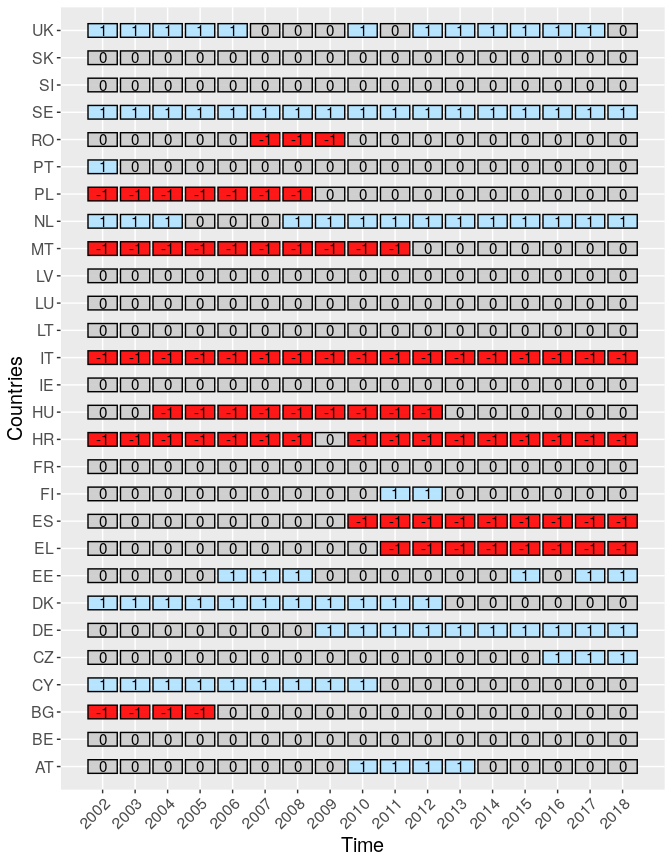

```r
# debug(graph_departure)
myGG <- graph_departure(res$res$departures,
                timeName = "time",
                displace = 0.25,
                displaceh = 0.45,
                dimeFontNum = 4,
                myfont_scale = 1.35,
                x_angle = 45,
                color_rect = c("-1"='red1', "0"='gray80',"1"='lightskyblue1'),
                axis_name_y = "Countries",
                axis_name_x = "Time",
                alpha_color = 0.9
                )
myGG
```

Any selection of countries is feasible:

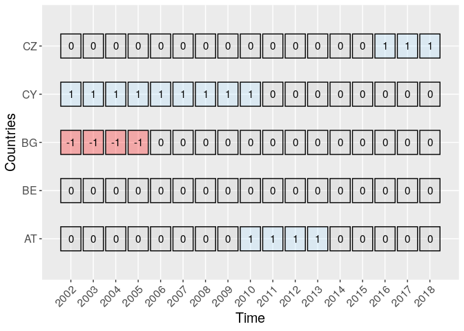

```r
#myWW1<- warnings()
myGG <- graph_departure(res$res$departures[,1:10],
                timeName = "time",
                displace = 0.25,
                displaceh = 0.45,
                dimeFontNum = 4,
                myfont_scale = 1.35,
                x_angle = 45,
                color_rect = c("-1"='red1', "0"='gray80',"1"='lightskyblue1'),
                axis_name_y = "Countries",
                axis_name_x = "Time",
                alpha_color = 0.29
                )

myGG
```

## 2.3 Gamma-convergence

We now introduce gamma convergence by an index based on ranks.

Let $y_{m,i,t}$ be the value of indicator $i$ for member state $m$ at time $t=0,1,\ldots, T$, and $\{ \tilde{y}_{m,i,t}: m \in A )$ the ranks for indicator $i$ over member states in the reference set $A$, for example $A = EU27$, at a given time $t$. The sum of ranks within member state $m$ is:
$$\tilde{y}^{(s)}_{m,i} = \sum_{t=0}^T \tilde{y}_{m,i,t}$$
thus the variance of the sum of ranks over the given interval
$$Var\left[ \{\tilde{y}^{(s)}_{m,i}: m \in A \} \right]$$
may be compared to the variance of ranks in the reference time $t=0$:
$$Var\left[ \{\tilde{y}_{m,i,0}: m \in A \} \right]$$

The Kendall index KI, with respect to aggregation $A$ of member states for the indicator $i$ over a given time interval is:
$$KI(A,i,T) = \frac{Var\left[ \{\tilde{y}^{(s)}_{m,i}: m \in A \} \right]
}{
(T+1)^2 ~~Var\left[\{\tilde{y}_{m,i,0}: m \in A \}\right] }$$

The measure of gamma-convergence is obtained with the following function:

```r
#wwTB
gamma_conv(emp_20_64_MS,2002,2016)
```

```
#> $res
#> [1] 0.7374964
#>
#> $msg
#> NULL
#>
#> $err
#> NULL
```

Note the starting time is zero, the reference, but first a copy of the dataset is performed.

```r
(timeCounTB <- testTB)
```

```
#> # A tibble: 6 x 4
#>    time countryA countryB countryC
#>   <dbl>    <dbl>    <dbl>    <dbl>
#> 1  2000      0.8      2.7      3.9
#> 2  2001      1.2      3.2      4.2
#> 3  2002      0.9      2.9      4.1
#> 4  2003      1.3      2.9      4
#> 5  2004      1.2      3.1      4.1
#> 6  2005      1.2      3        4
```

Now we move to ranks within time using *rank()*:

```r
tmp <- c( 3, 6, 9, 1, 12)
rank(tmp)
```

```
#> [1] 2 3 4 1 5
```

therefore with the above data:

```r
# debug(gamma_conv)
(gamma_conv(timeCounTB,ref=2000,last=2005,timeName = "time"))
```

```
#> $res
#> [1] 0.7346939
#>
#> $msg
#> NULL
#>
#> $err
#> NULL
```

```r
(gamma_conv(timeCounTB,ref=2000,last=2004,timeName = "time"))
```

```
#> $res
#> [1] 0.6944444
#>
#> $msg
#> NULL
#>
#> $err
#> NULL
```

```r
(gamma_conv(timeCounTB,ref=2000,last=2003,timeName = "time"))
```

```
#> $res
#> [1] 0.64
#>
#> $msg
#> NULL
#>
#> $err
#> NULL
```

```r
(gamma_conv(timeCounTB,ref=2000,last=2002,timeName = "time"))
```

```
#> $res
#> [1] 0.5625
#>
#> $msg
#> NULL
#>
#> $err
#> NULL
```

```r
(gamma_conv(timeCounTB,ref=2000,last=2001,timeName = "time"))
```

```
#> $res
#> [1] 0.4444444
#>
#> $msg
#> NULL
#>
#> $err
#> NULL
```

and changing reference year:

```r
(gamma_conv(timeCounTB,ref=2001,last=2005,timeName = "time"))
```

[output not shown]

```r
(gamma_conv(timeCounTB,ref=2002,last=2004,timeName = "time"))
```

[output not shown]

Now we permutate values and calculate gamma-convergence:

```r
timeCounTB2 <- timeCounTB
timeCounTB2[2,2:4] <-  timeCounTB[2,4:2]
timeCounTB2[4,2:4] <-  timeCounTB[4,c(4,2,3)]
timeCounTB2
```

```
#> # A tibble: 6 x 4
#>    time countryA countryB countryC
#>   <dbl>    <dbl>    <dbl>    <dbl>
#> 1  2000      0.8      2.7      3.9
#> 2  2001      4.2      3.2      1.2
#> 3  2002      0.9      2.9      4.1
#> 4  2003      4        1.3      2.9
#> 5  2004      1.2      3.1      4.1
#> 6  2005      1.2      3        4
```

```r
gamma_conv(timeCounTB2,last=2005,ref=2000, timeName = "time",printRanks = T)
```

```
#> Ranks:
#>      countryA countryB countryC
#> [1,]        1        2        3
#> [2,]        3        2        1
#> [3,]        1        2        3
#> [4,]        3        1        2
#> [5,]        1        2        3
#> [6,]        1        2        3
#> $res
#> [1] 0.1428571
#>
#> $msg
#> NULL
#>
#> $err
#> NULL
```

and after random permutation:

```r
timeCounTB3 <- cbind(timeCounTB[,1],t(apply(timeCounTB,1,
                                        function(vet)vet[sample(2:4,3)])))
timeCounTB3
```

```
#>   time   1   2   3
#> 1 2000 0.8 2.7 3.9
#> 2 2001 3.2 1.2 4.2
#> 3 2002 0.9 4.1 2.9
#> 4 2003 1.3 4.0 2.9
#> 5 2004 1.2 3.1 4.1
#> 6 2005 3.0 1.2 4.0
```

```r
(gamma_conv(timeCounTB3,last=2005,ref=2000, timeName = "time",printRanks = T))
```

```
#> Ranks:
#>      1 2 3
#> [1,] 1 2 3
#> [2,] 2 1 3
#> [3,] 1 3 2
#> [4,] 1 3 2
#> [5,] 1 2 3
#> [6,] 2 1 3
#> $res
#> [1] 0.3265306
#>
#> $msg
#> NULL
#>
#> $err
#> NULL
```

## 2.4 Delta-convergence

Delta-convergence can be calculated as follows:

```r
delta_conv(timeCounTB)
```

```
#> $res
#> # A tibble: 6 x 2
#>    time delta
#>   <dbl> <dbl>
#> 1  2000  4.30
#> 2  2001  4
#> 3  2002  4.40
#> 4  2003  3.8
#> 5  2004  3.90
#> 6  2005  3.8
#>
#> $msg
#> NULL
#>
#> $err
#> NULL
```

## 2.5 Absolute change

Absolute change as described in the reserved Eurofound Annex is defined as:
$$\Delta y_{m,i,t} = y_{m,i,t} - y_{m,i,t-1}$$
for country $m$, indicator $i$ at time $t$.

The R function *abso_change* calculates the above quantity, for example in the *emp_20_64_MS* dataset

```r
data(emp_20_64_MS)
mySTB <- abso_change(emp_20_64_MS,
                        time_0 = 2005,
                        time_t = 2010,
                        all_within=TRUE,
                        timeName = "time")
names(mySTB$res)
```

```
#> [1] "abso_change"        "sum_abs_change"     "average_abs_change"
```

thus the above equation results in:

```r
mySTB$res$abso_change
```

[output not shown]

The sum of absolute values
$$\sum_{t=t_0+1}^{} | \Delta y_{m,i,t}|$$
is:

```r
round(mySTB$res$sum_abs_change,4)
```

```
#>   AT   BE   BG   CY   CZ   DE   DK   EE   EL   ES   FI   FR   HR   HU   IE   IT
#>  7.7  3.4 11.9  4.3  3.5  5.9  3.5  8.6  3.0  6.5  3.0  2.3  6.0  2.3  5.1  3.9
#>   LT   LU   LV   MT   NL   PL   PT   RO   SE   SI   SK   UK
#>  6.9  3.6  8.9  2.2  5.9  6.4  2.4  3.3  3.3  6.2  7.0  0.9
```

and such sum can be divided by the number of pair of years so that the result is an average per pair of years:

```r
round(mySTB$res$average_abs_change,4)
```

```
#>   AT   BE   BG   CY   CZ   DE   DK   EE   EL   ES   FI   FR   HR   HU   IE   IT
#> 1.54 0.68 2.38 0.86 0.70 1.18 0.70 1.72 0.60 1.30 0.60 0.46 1.20 0.46 1.02 0.78
#>   LT   LU   LV   MT   NL   PL   PT   RO   SE   SI   SK   UK
#> 1.38 0.72 1.78 0.44 1.18 1.28 0.48 0.66 0.66 1.24 1.40 0.18
```

## 2.6 Convergence measures on Eurofound lifesatisf indicator

Here we assume that larger the index, better the performance.

Let’s load the Eurofound indicator *lifesatisf*:

```r
workDF <- extract_indicator_EUF(
  indicator_code ="lifesatisf", #Code_in_database
  fromTime=2000,
  toTime =2018,
  gender= c("Total","Females","Males")[1],
  countries =  convergEU_glb()$EU27_2020$memberStates$codeMS)
workDF
```

```
#> $res
#> # A tibble: 4 x 29
#>    time sex      AT    BE    BG    CY    CZ    DE    DK    EE    EL    ES    FI
#>   <dbl> <chr> <dbl> <dbl> <dbl> <dbl> <dbl> <dbl> <dbl> <dbl> <dbl> <dbl> <dbl>
#> 1  2003 Total  7.85  7.52  4.47  7.22  6.57  7.36  8.47  5.94  6.69  7.49  8.14
#> 2  2007 Total  6.95  7.54  5.01  7.05  6.59  7.16  8.48  6.72  6.58  7.25  8.23
#> 3  2011 Total  7.66  7.38  5.55  7.16  6.43  7.20  8.37  6.28  6.16  7.47  8.08
#> 4  2016 Total  7.92  7.31  5.62  6.54  6.48  7.31  8.19  6.73  5.26  6.95  8.07
#> # … with 16 more variables: FR <dbl>, HR <dbl>, HU <dbl>, IE <dbl>, IT <dbl>,
#> #   LT <dbl>, LU <dbl>, LV <dbl>, MT <dbl>, NL <dbl>, PL <dbl>, PT <dbl>,
#> #   RO <dbl>, SE <dbl>, SI <dbl>, SK <dbl>
#>
#> $msg
#> NULL
#>
#> $err
#> NULL
```

```r
wDF <- workDF$res
```

then we ask if it is complete or some missing values are present:

```r
check_data(select(wDF,-sex),timeName="time")
```

```
#> $res
#> NULL
#>
#> $msg
#> NULL
#>
#> $err
#> [1] "Error: one or more missing values in the dataframe."
```

thus at least one missing value is present. In the next step, imputation of missing values is performed:

```r
wDFI <- impute_dataset(select(wDF,-sex),
               countries= names(select(wDF,-sex,-time)),
               timeName = "time",
               tailMiss = c("cut", "constant")[2],
               headMiss = c("cut", "constant")[1])
```

and some checking is done:

```r
check_data(wDFI$res,timeName="time")
```

```
#> $res
#> [1] TRUE
#>
#> $msg
#> NULL
#>
#> $err
#> NULL
```

which returns TRUE.

First, we calculate the EU unweighted average of emp:

```r
wwTB <- (wDFI$res %>%
   average_clust(timeName="time",cluster="EU27"))$res

wwTB$EU27
```

```
#> [1] 6.829626 6.984789 7.014334 6.978321
```

Time series can be plotted:

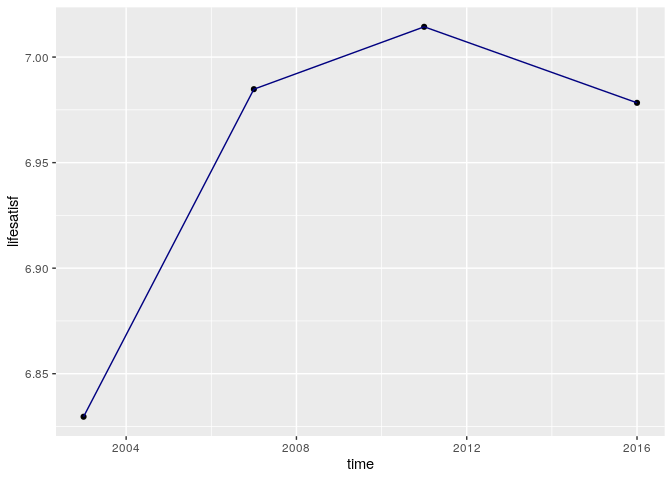

```r
mini_EU <- min(wwTB$EU27)
maxi_EU <- max(wwTB$EU27)

qplot(time, EU27, data=wwTB,
      ylim=c(mini_EU,maxi_EU))+geom_line(colour="navy blue")+
      ylab("lifesatisf")
```

### 2.6.1 Beta convergence

Now the beta-convergence is calculated for just two years:

```r
betaRes <- beta_conv(wDFI$res,time_0=2007, time_t=2011, all_within=FALSE)
betaRes
```

```
#> $res
#> $res$workTB
#> # A tibble: 27 x 3
#>    deltaIndic indic countries
#>         <dbl> <dbl> <chr>
#>  1    0.0244   1.94 AT
#>  2   -0.00553  2.02 BE
#>  3    0.0256   1.61 BG
#>  4    0.00403  1.95 CY
#>  5   -0.00623  1.89 CZ
#>  6    0.00138  1.97 DE
#>  7   -0.00316  2.14 DK
#>  8   -0.0171   1.91 EE
#>  9   -0.0165   1.88 EL
#> 10    0.00719  1.98 ES
#> # … with 17 more rows
#>
#> $res$model
#>
#> Call:
#> stats::lm(formula = deltaIndic ~ indic, data = workTB)
#>
#> Coefficients:
#> (Intercept)        indic
#>     0.11155     -0.05679
#>
#>
#> $res$summary
#> # A tibble: 2 x 5
#>   term        estimate std.error statistic p.value
#>   <chr>          <dbl>     <dbl>     <dbl>   <dbl>
#> 1 (Intercept)   0.112     0.0314      3.56 0.00153
#> 2 indic        -0.0568    0.0162     -3.51 0.00171
#>
#> $res$beta1
#> [1] -0.05678881
#>
#> $res$adj.r.squared
#> [1] 0.3037316
#>
#>
#> $msg
#> NULL
#>
#> $err
#> NULL
```

A plot of transformed data and the straight line may be useful:

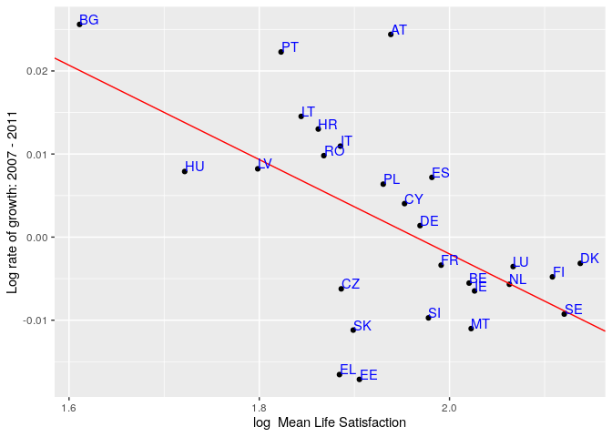

```r
mybetaplot<-beta_conv_graph(betaRes,
                            indiName = 'Mean Life Satisfaction',
                            time_0 = 2007,
                            time_t = 2011)
mybetaplot
```

Note that label are replicated as many times as the number of included subsequent years.

### 2.6.2 Sigma convergence

Here we go with calculating the sigma-convergence:

```r
mysigmares<-sigma_conv(wwTB)
#mysigmares
```

It is also possible to obtain a graphical representation of the standard deviation and the coefficient of variation obtained for the Sigma convergence by invoking the *sigma_conv_graph* fucntion as follows:

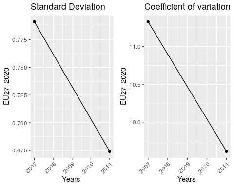

```r
mysigmaplot<-sigma_conv_graph(sigmaconvOut=mysigmares,
         time_0 = 2007,
         time_t = 2011,
        aggregation='EU27_2020')
mysigmaplot
```

### 2.6.3 Gamma convergence

Let’s reload Eurofound data:

```r
workDF <- extract_indicator_EUF(
  indicator_code ="lifesatisf", #Code_in_database
  fromTime=2000,
  toTime =2018,
  gender= c("Total","Females","Males")[1],
  countries =  convergEU_glb()$EU27_2020$memberStates$codeMS)
wDFI <- impute_dataset(select(workDF$res,-sex),
               countries= names(select(wDF,-sex,-time)),
               timeName = "time",
               tailMiss = c("cut", "constant")[2],
               headMiss = c("cut", "constant")[1])

check_data(wDFI$res,timeName="time")
```

```
#> $res
#> [1] TRUE
#>
#> $msg
#> NULL
#>
#> $err
#> NULL
```

Now gamma-convergence is computed:

```r
gamma_conv(wDFI$res,ref=2003,last=2016,timeName = "time")
```

```
#> $res
#> [1] 0.5879853
#>
#> $msg
#> NULL
#>
#> $err
#> NULL
```

or equivalently:

```r
tmpRes <- gamma_conv(wDFI$res,ref=2007,last=2011,timeName = "time")
```

Indeed there is the possbility of performing calculation for each pair of subsequent years in the dataset, that is, each year is the reference of the subsequent year:

```r
wDFI$res
```

```
#> # A tibble: 4 x 28
#>    time    AT    BE    BG    CY    CZ    DE    DK    EE    EL    ES    FI    FR
#>   <dbl> <dbl> <dbl> <dbl> <dbl> <dbl> <dbl> <dbl> <dbl> <dbl> <dbl> <dbl> <dbl>
#> 1  2003  7.85  7.52  4.47  7.22  6.57  7.36  8.47  5.94  6.69  7.49  8.14  6.96
#> 2  2007  6.95  7.54  5.01  7.05  6.59  7.16  8.48  6.72  6.58  7.25  8.23  7.32
#> 3  2011  7.66  7.38  5.55  7.16  6.43  7.20  8.37  6.28  6.16  7.47  8.08  7.23
#> 4  2016  7.92  7.31  5.62  6.54  6.48  7.31  8.19  6.73  5.26  6.95  8.07  7.17
#> # … with 15 more variables: HR <dbl>, HU <dbl>, IE <dbl>, IT <dbl>, LT <dbl>,
#> #   LU <dbl>, LV <dbl>, MT <dbl>, NL <dbl>, PL <dbl>, PT <dbl>, RO <dbl>,
#> #   SE <dbl>, SI <dbl>, SK <dbl>
```

```r
gamma_conv_msteps(wDFI$res,
                  startTime=2003,
                  endTime=2016,
                  timeName = "time")
```

```
#> $res
#> # A tibble: 4 x 2
#>    time gammaConv
#>   <dbl>     <dbl>
#> 1  2003    NA
#> 2  2007     0.418
#> 3  2011     0.526
#> 4  2016     0.588
#>
#> $msg
#> NULL
#>
#> $err
#> NULL
```

### 2.6.4 Delta convergence

Let $y_{m,i,t}$ be the value of indicator $i$ for member state $m$ at time $t$, and $y^{(M)}_{i,t}$ the maximum value over member states in the reference set $A$, for example $A = EU27$:
$$y^{(M)}_{i,t} = max(\{ y_{m,i,t}: m \in A\})$$

The distance of a member state $m$ from the top performer at time $i$ is:
$$y^{(M)}_{i,t} - y_{m,i,t}$$
thus the overall distance at time $t$, called delta, is the sum of distances over the reference set $A$ of MS:
$$\delta_{i,t} = \sum_{m \in A} (y^{(M)}_{i,t} - y_{m,i,t})$$
for the considered indicator $i$.

The measure of delta-convergence is obtained as follows:

```r
delta_conv(wwTB)
```

```
#> $res
#> # A tibble: 4 x 2
#>    time delta
#>   <dbl> <dbl>
#> 1  2003  46.0
#> 2  2007  41.8
#> 3  2011  38.0
#> 4  2016  34.0
#>
#> $msg
#> NULL
#>
#> $err
#> NULL
```

It must be noted that the *delta_conv* function allows to obtain also the declaration of convergence. To this end, the argument *extended* should be specified as *TRUE*. For example, for the *wwTB* indicator the syntax is as follows:

```r
delta_conv(wwTB,"time", extended=TRUE)
```

```
#> $res
#> $res$delta_conv
#> # A tibble: 4 x 2
#>    time delta
#>   <dbl> <dbl>
#> 1  2003  46.0
#> 2  2007  41.8
#> 3  2011  38.0
#> 4  2016  34.0
#>
#> $res$differences
#>             AT        BE       BG       CY       CZ       DE DK       EE
#> [1,] 0.6245208 0.9556756 4.003694 1.250645 1.904858 1.113082  0 2.534678
#> [2,] 1.5314507 0.9352727 3.469857 1.430196 1.883980 1.314598  0 1.756762
#> [3,] 0.7128654 0.9938769 2.823287 1.209136 1.939715 1.168355  0 2.095294
#> [4,] 0.2691503 0.8841901 2.568287 1.657201 1.713479 0.885087  0 1.464275
#>            EL        ES        FI       FR       HR       HU        IE       IT
#> [1,] 1.779027 0.9809632 0.3344421 1.508648 2.035054 2.534398 0.7697177 1.255543
#> [2,] 1.896363 1.2247257 0.2450380 1.154050 2.041460 2.884686 0.8919230 1.889798
#> [3,] 2.211353 0.9066143 0.2946043 1.145797 1.591188 2.598653 0.9794941 1.488251
#> [4,] 2.930435 1.2417102 0.1190214 1.025349 1.860298 1.677889 0.5078416 1.635120
#>            LT        LU       LV        MT        NL        PL       PT
#> [1,] 3.028715 0.7834425 2.897604 1.1496062 0.9260612 2.3119373 2.481104
#> [2,] 2.156122 0.5780816 2.438259 0.9191999 0.6090589 1.5864158 2.288289
#> [3,] 1.671255 0.5828137 2.129854 1.1383724 0.6792879 1.3019018 1.604687
#> [4,] 1.709892 0.2899728 1.869513 0.6240749 0.4548769 0.9941764 1.321342
#>            RO        SE       SI       SK     EU27
#> [1,] 2.348566 0.5827713 1.429040 2.815222 1.642186
#> [2,] 2.003722 0.1419497 1.250872 1.800439 1.493428
#> [3,] 1.638209 0.3387566 1.419971 1.986291 1.357403
#> [4,] 1.692563 0.2608399 1.338965 1.789471 1.214260
#>
#> $res$difference_last_first
#>          AT          BE          BG          CY          CZ          DE
#> -0.35537052 -0.07148552 -1.43540668  0.40655661 -0.19137859 -0.22799492
#>          DK          EE          EL          ES          FI          FR
#>  0.00000000 -1.07040215  1.15140772  0.26074696 -0.21542072 -0.48329926
#>          HR          HU          IE          IT          LT          LU
#> -0.17475605 -0.85650873 -0.26187611  0.37957668 -1.31882334 -0.49346972
#>          LV          MT          NL          PL          PT          RO
```

[output cut: 10 more lines]

```
#> $res$converg_ini_last
#> [1] TRUE
#>
#> $res$label_conver
#> [1] "convergence"
#>
#> $res$diffe_delta
#> [1] -11.98192
#>
#>
#> $msg
#> NULL
#>
#> $err
#> NULL
```

It is also useful to evaluate how much a collection of **MS** deviates from the **EU** mean for a given indicator and a period of time. In order to obtain this further information the *demea_change* function has been implemented in the *convergEU* package:

```
#> $res
#> $res$resDiffe
#> # A tibble: 4 x 29
#>    time      AT    BE    BG      CY     CZ    DE    DK     EE     EL      ES
#>   <dbl>   <dbl> <dbl> <dbl>   <dbl>  <dbl> <dbl> <dbl>  <dbl>  <dbl>   <dbl>
#> 1  2003  1.02   0.687 -2.36  0.392  -0.263 0.529  1.64 -0.892 -0.137  0.661
#> 2  2007 -0.0380 0.558 -1.98  0.0632 -0.391 0.179  1.49 -0.263 -0.403  0.269
#> 3  2011  0.645  0.364 -1.47  0.148  -0.582 0.189  1.36 -0.738 -0.854  0.451
#> 4  2016  0.945  0.330 -1.35 -0.443  -0.499 0.329  1.21 -0.250 -1.72  -0.0275
#> # … with 18 more variables: FI <dbl>, FR <dbl>, HR <dbl>, HU <dbl>, IE <dbl>,
#> #   IT <dbl>, LT <dbl>, LU <dbl>, LV <dbl>, MT <dbl>, NL <dbl>, PL <dbl>,
#> #   PT <dbl>, RO <dbl>, SE <dbl>, SI <dbl>, SK <dbl>, EU27 <dbl>
#>
#> $res$diffe_abs_diff
#> # A tibble: 3 x 29
#>    time     AT      BE     BG      CY      CZ      DE     DK     EE    EL     ES
#>   <dbl>  <dbl>   <dbl>  <dbl>   <dbl>   <dbl>   <dbl>  <dbl>  <dbl> <dbl>  <dbl>
#> 1  2007 -0.980 -0.128  -0.385 -0.328   0.128  -0.350  -0.149 -0.629 0.266 -0.393
#> 2  2011  0.607 -0.195  -0.511  0.0850  0.192   0.0102 -0.136  0.475 0.451  0.182
#> 3  2016  0.301 -0.0335 -0.112  0.295  -0.0831  0.140  -0.143 -0.488 0.862 -0.423
#> # … with 18 more variables: FI <dbl>, FR <dbl>, HR <dbl>, HU <dbl>, IE <dbl>,
#> #   IT <dbl>, LT <dbl>, LU <dbl>, LV <dbl>, MT <dbl>, NL <dbl>, PL <dbl>,
#> #   PT <dbl>, RO <dbl>, SE <dbl>, SI <dbl>, SK <dbl>, EU27 <dbl>
#>
#> $res$stats
#> # A tibble: 28 x 4
#>    MS    negaSum posiSum  posi
#>    <chr>   <dbl>   <dbl> <int>
#>  1 AT    -0.980    0.907     1
#>  2 BE    -0.356    0         2
#>  3 BG    -1.01     0         3
#>  4 CY    -0.328    0.380     4
#>  5 CZ    -0.0831   0.320     5
#>  6 DE    -0.350    0.150     6
#>  7 DK    -0.428    0         7
#>  8 EE    -1.12     0.475     8
#>  9 EL     0        1.58      9
#> 10 ES    -0.816    0.182    10
#> # … with 18 more rows
#>
#> $res$miniX
#> [1] -1.117033
#>
#> $res$maxiX
#> [1] 1.579333
#>
#> $res$res_graph
```

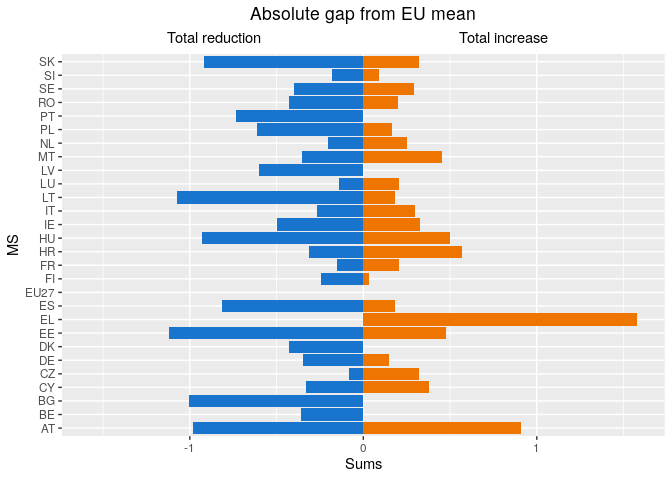

```r
res1<-demea_change(wwTB,
                   timeName="time",
                   time_0 = 2003,
                   time_t = 2016,
                   sele_countries= NA,
                   doplot=TRUE)
res1
```

To plot the calculated differences, the user should invoke the *plot* function as follows:

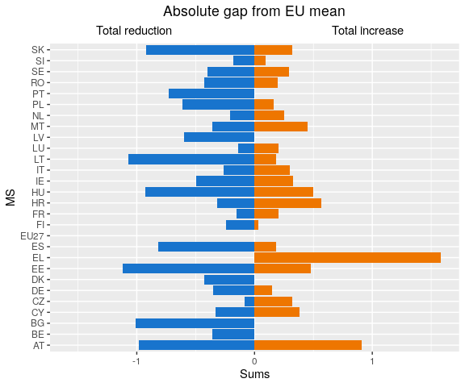

```r
plot(res1$res$res_graph)
```

# 3 Support functions

There are several auxiliary functions that help to prepare the tidy dataset time by member states (MS, that is countries in EU), which is needed in almost all computations. Here the most important resources are described.

## 3.1 Summaries and clusters of countries

An important summary is obtained  
as unweighted average of country values. The cluster of considered countries may be specified and is also stored within the function generating global static objects and tables, called *convergEU_glb()*. The illustration of this function exploits the *emp_20_64_MS* dataframe in *convergEU* package.

First note that the EU area is made by the following MS:

```r
convergEU_glb()$Eurozone
```

```
#> $dates
#> [1] NA NA
#>
#> $memberStates
#> # A tibble: 19 x 2
#>    MS          codeMS
#>    <chr>       <chr>
#>  1 Austria     AT
#>  2 Belgium     BE
#>  3 Cyprus      CY
#>  4 Estonia     EE
#>  5 Finland     FI
#>  6 France      FR
#>  7 Germany     DE
#>  8 Greece      EL
#>  9 Ireland     IE
#> 10 Italy       IT
#> 11 Latvia      LV
#> 12 Lithuania   LT
#> 13 Luxembourg  LU
#> 14 Malta       MT
#> 15 Netherlands NL
#> 16 Portugal    PT
#> 17 Slovakia    SK
#> 18 Slovenia    SI
#> 19 Spain       ES
```

```r
convergEU_glb()$EU27_2020
```

```
#> $dates
#> [1] "01/02/2020" "00/00/0000"
#>
#> $memberStates
#> # A tibble: 27 x 2
#>    MS          codeMS
#>    <chr>       <chr>
#>  1 Belgium     BE
#>  2 Denmark     DK
#>  3 France      FR
#>  4 Germany     DE
#>  5 Greece      EL
#>  6 Ireland     IE
#>  7 Italy       IT
#>  8 Luxembourg  LU
#>  9 Netherlands NL
#> 10 Portugal    PT
#> # … with 17 more rows
```

The list of known MS labels is shown in the appendix.

For example, the unweighted average in the *emp_20_64_MS* dataset is:

```r
testTB <- emp_20_64_MS
average_clust(testTB,timeName = "time",cluster = "EU27")$res[,c(1,30)]
```

```
#> # A tibble: 17 x 2
#>     time  EU27
#>    <dbl> <dbl>
#>  1  2002  67.3
#>  2  2003  67.5
#>  3  2004  67.6
#>  4  2005  68.2
#>  5  2006  69.4
#>  6  2007  70.4
#>  7  2008  70.8
#>  8  2009  68.8
#>  9  2010  67.9
#> 10  2011  67.9
#> 11  2012  67.8
#> 12  2013  67.8
#> 13  2014  68.7
#> 14  2015  69.7
#> 15  2016  70.8
#> 16  2017  72.3
#> 17  2018  73.7
```

while for EU12 is:

```r
average_clust(testTB,timeName = "time",cluster = "EU12")$res[,c(1,30)]
```

```
#> # A tibble: 17 x 2
#>     time  EU12
#>    <dbl> <dbl>
#>  1  2002  69.1
#>  2  2003  69.1
#>  3  2004  69.4
#>  4  2005  69.9
#>  5  2006  70.6
#>  6  2007  71.3
#>  7  2008  71.4
#>  8  2009  69.9
#>  9  2010  69.2
#> 10  2011  68.6
#> 11  2012  68.0
#> 12  2013  67.8
#> 13  2014  68.4
#> 14  2015  69.2
#> 15  2016  70.1
#> 16  2017  71.2
#> 17  2018  72.3
```

```r
average_clust(testTB,timeName = "TTime",cluster = "EUspirit")
```

```
#> $res
#> NULL
#>
#> $msg
#> NULL
#>
#> $err
#> [1] "Error: Time variable not in the dataframe."
```

## 3.2 Imputing missing values using a straight line

The basic imputation method is deterministic, like the average of interval endpoints, but it assumes that a linear change of an indicator happened between the two observed time points flanking a chunk of missing values.

```r
intervalTime <-  c(1999,2000,2001)
intervalMeasure <- c( 66.5, NA,87.2)
currentData <- tibble(time= intervalTime, veval= intervalMeasure)
currentData
```

```
#> # A tibble: 3 x 2
#>    time veval
#>   <dbl> <dbl>
#> 1  1999  66.5
#> 2  2000  NA
#> 3  2001  87.2
```

```r
resImputed <- impute_dataset(currentData,
                           countries = "veval",
                           timeName = "time",
                           tailMiss = c("cut", "constant")[2],
                           headMiss = c("cut", "constant")[2])
resImputed
```

```
#> $res
#> # A tibble: 3 x 2
#>    time veval
#>   <dbl> <dbl>
#> 1  1999  66.5
#> 2  2000  76.8
#> 3  2001  87.2
#>
#> $msg
#> NULL
#>
#> $err
#> NULL
```

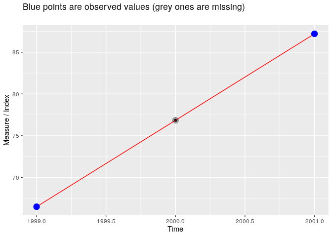

If several missing values are present in a row

```r
intervalTime <-  c(1999,2000,2001,2002,2003)
intervalMeasure <- c( 66.5, NA,NA,NA,87.2)
currentData <- tibble(time= intervalTime, veval= intervalMeasure)
currentData
```

```
#> # A tibble: 5 x 2
#>    time veval
#>   <dbl> <dbl>
#> 1  1999  66.5
#> 2  2000  NA
#> 3  2001  NA
#> 4  2002  NA
#> 5  2003  87.2
```

```r
resImputed <- impute_dataset(currentData,
                           countries = "veval",
                           timeName = "time",
                           tailMiss = c("cut", "constant")[2],
                           headMiss = c("cut", "constant")[2])
tmp <-  as.data.frame(currentData[ c(1,5),] )
tmp2 <- as.data.frame(resImputed$res[2:4,] )

resImputed
```

```
#> $res
#> # A tibble: 5 x 2
#>    time veval
#>   <dbl> <dbl>
#> 1  1999  66.5
#> 2  2000  71.7
#> 3  2001  76.9
#> 4  2002  82.0
#> 5  2003  87.2
#>
#> $msg
#> NULL
#>
#> $err
#> NULL
```

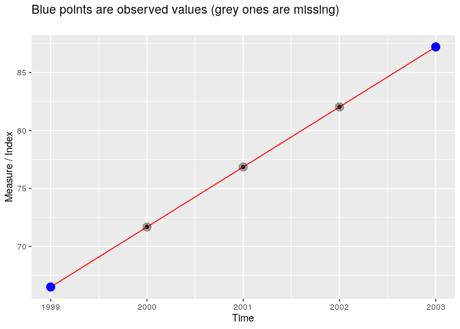

## 3.3 Weighted average smoothing of a complete dataset

It may be of interest to assume that part of the variability observed in a country on a given index is **not structural**, i.e. not due to causal determinants by to transient fluctuations. Furthermore, the interest here is not directed towards prediction but on smoothing values observed in the whole considered time interval.

In such a case a smoothing procedure remove sudden large changes showing a less variable time serie than the original.

Given that here short time series (panel data) are considered, a three points weighted average is proposed. The smoother substitutes an original raw value $y_{m,i,t}$ of country $m$ indicator $i$ at time $t$ with the weighted average
$$\check{y}_{m,i,t} = y_{m,i,t-1} ~ (1-w)/2 +w ~y_{m,i,t} +y_{m,i,t+1} ~(1-w)/2$$
where $0< w \leq 1$. The special case $w=1$ corresponds to no smoothing. In case of missing values an NA is returned. If the weight is outside the intervel $(0,1]$ then a NA is returned. The first and last values are smoothed using weights $w$ and $1-w$.

After loading data, imputation takes place and finally smoothing is performed. Now, countries IT and DE are considered to illustrate the procedure. First check if missing values are present:

```r
workTB <- dplyr::select(emp_20_64_MS, time, IT,DE)
check_data(workTB)
```

```
#> $res
#> [1] TRUE
#>
#> $msg
#> NULL
#>
#> $err
#> NULL
```

thus checking is passed, so we go with the smoothing step after deleting the time variable:

```r
resSM <- smoo_dataset(select(workTB,-time), leadW = 0.149, timeTB= select(workTB,time))
resSM
```

```
#> # A tibble: 17 x 3
#>     time    IT    DE
#>    <dbl> <dbl> <dbl>
#>  1  2002  60.0  68.5
#>  2  2003  60.4  68.4
#>  3  2004  60.9  68.8
#>  4  2005  62.0  69.5
#>  5  2006  62.1  71.1
#>  6  2007  62.7  72.6
#>  7  2008  62.3  73.6
#>  8  2009  61.9  74.5
#>  9  2010  61.3  75.3
#> 10  2011  61.0  76.0
#> 11  2012  60.4  76.9
#> 12  2013  60.3  77.3
#> 13  2014  60.1  77.7
#> 14  2015  60.7  78.1
#> 15  2016  61.4  78.6
#> 16  2017  62.3  79.2
#> 17  2018  62.4  79.3
```

and for a comparison:

```r
compaTB <- select(bind_cols(workTB, select(resSM,-time)), time,IT,IT1,DE,DE1)
compaTB
```

```
#> # A tibble: 17 x 5
#>     time    IT   IT1    DE   DE1
#>    <dbl> <dbl> <dbl> <dbl> <dbl>
#>  1  2002  59.2  60.0  68.8  68.5
#>  2  2003  60.1  60.4  68.4  68.4
#>  3  2004  61.7  60.9  67.9  68.8
#>  4  2005  61.5  62.0  69.4  69.5
#>  5  2006  62.4  62.1  71.1  71.1
#>  6  2007  62.7  62.7  72.9  72.6
#>  7  2008  62.9  62.3  74    73.6
#>  8  2009  61.6  61.9  74.2  74.5
#>  9  2010  61    61.3  75    75.3
#> 10  2011  61    61.0  76.5  76.0
#> 11  2012  60.9  60.4  76.9  76.9
#> 12  2013  59.7  60.3  77.3  77.3
#> 13  2014  59.9  60.1  77.7  77.7
#> 14  2015  60.5  60.7  78    78.1
#> 15  2016  61.6  61.4  78.6  78.6
#> 16  2017  62.3  62.3  79.2  79.2
#> 17  2018  63    62.4  79.9  79.3
```

A graphical output shows changes for “IT”, with original index in blue and smoothed index in red:

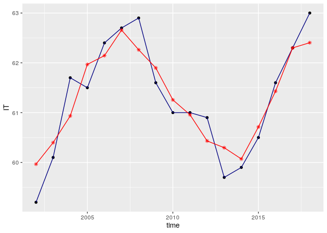

```r
qplot(time,IT,data=compaTB) +
  geom_line(colour="navyblue") +
  geom_line(aes(x=time,y=IT1),colour="red") +
  geom_point(aes(x=time,y=IT1),colour="red",shape=8)
```

Similarly for Germany, i.e. “DE”:

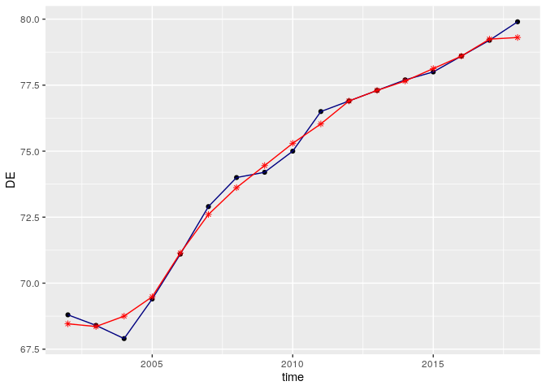

```r
qplot(time,DE,data=compaTB) +
  geom_line(colour="navyblue") +
  geom_line(aes(x=time,y=DE1),colour="red") +
  geom_point(aes(x=time,y=DE1),colour="red",shape=8)
```

A weight equal to 1 leaves data unchanged:

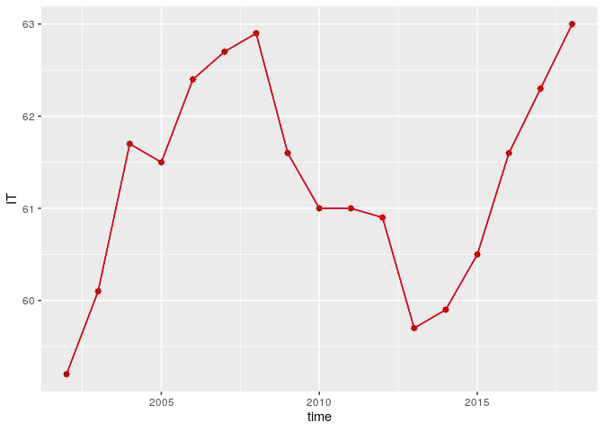

```r
resSM <- smoo_dataset(select(workTB,-time), leadW = 1, timeTB= select(workTB,time))
compaTB <- select(bind_cols(workTB, select(resSM,-time)), time,IT,IT1,DE,DE1)
qplot(time,IT,data=compaTB) +
  geom_line(colour="navyblue") +
  geom_line(aes(x=time,y=IT1),colour="red") +
  geom_point(aes(x=time,y=IT1),colour="red",shape=8)
```

**A time window larger than $3$ could be considered, but deep thoughts are recommended on how much economic and social changes may happen in $5$ consecutive years.**

## 3.4 Moving Average smoother

Several alternative smoothing algorithm are available in R. Classical *ma* smoothers are also available from the *caTools* package.

The emp_20_64_MS dataset is now chosen for example, first with Italy and then with Germany as member states of interest.

```r
data(emp_20_64_MS)
cuTB <- dplyr::tibble(ITori =emp_20_64_MS$IT)
cuTB <- dplyr::mutate(cuTB,time =emp_20_64_MS$time)
```

At the begining and end of this series values are averages on smaller and smaller number of observations on the tails:

```r
cuTB <-  dplyr:: mutate(cuTB, IT_k_3= runmean(emp_20_64_MS$IT, k=3,
        alg=c("C", "R", "fast", "exact")[4],
        endrule=c("mean", "NA", "trim", "keep", "constant", "func")[4],
        align = c("center", "left", "right")[1]))

cuTB <-  dplyr:: mutate(cuTB, IT_k_5= runmean(emp_20_64_MS$IT, k=5,
        alg=c("C", "R", "fast", "exact")[4],
        endrule=c("mean", "NA", "trim", "keep", "constant", "func")[4],
        align = c("center", "left", "right")[1]))

cuTB <-  dplyr:: mutate(cuTB, IT_k_7= runmean(emp_20_64_MS$IT, k=7,
        alg=c("C", "R", "fast", "exact")[4],
        endrule=c("mean", "NA", "trim", "keep", "constant", "func")[4],
        align = c("center", "left", "right")[1]))
```

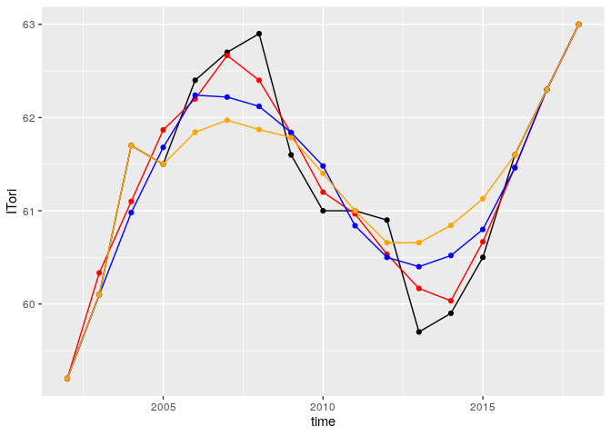

```r
myG <- ggplot(cuTB,aes(x=time,y=ITori))+geom_line()+geom_point()+
       geom_line(aes(x=time,y=IT_k_3),colour="red")+
       geom_point(aes(x=time,y=IT_k_3),colour="red")+
       #
       geom_line(aes(x=time,y=IT_k_5),colour="blue")+
       geom_point(aes(x=time,y=IT_k_5),colour="blue")+
       #
       geom_line(aes(x=time,y=IT_k_7),colour="orange")+
       geom_point(aes(x=time,y=IT_k_7),colour="orange")+
       theme(legend.position = c(.5, .5),
              legend.title = element_text(face = "bold"))

myG
```

For Germany, a similar implementation provides the following result:

```r
cuTB <- dplyr::mutate(cuTB, DEori =emp_20_64_MS$DE)

cuTB <-  dplyr:: mutate(cuTB, DE_k_3= runmean(emp_20_64_MS$DE, k=3,
        alg=c("C", "R", "fast", "exact")[4],
        endrule=c("mean", "NA", "trim", "keep", "constant", "func")[4],
        align = c("center", "left", "right")[1]))

cuTB <-  dplyr:: mutate(cuTB, DE_k_5= runmean(emp_20_64_MS$DE, k=5,
        alg=c("C", "R", "fast", "exact")[4],
        endrule=c("mean", "NA", "trim", "keep", "constant", "func")[4],
        align = c("center", "left", "right")[1]))

cuTB <-  dplyr:: mutate(cuTB, DE_k_7= runmean(emp_20_64_MS$DE, k=7,
        alg=c("C", "R", "fast", "exact")[4],
        endrule=c("mean", "NA", "trim", "keep", "constant", "func")[4],
        align = c("center", "left", "right")[1]))
```

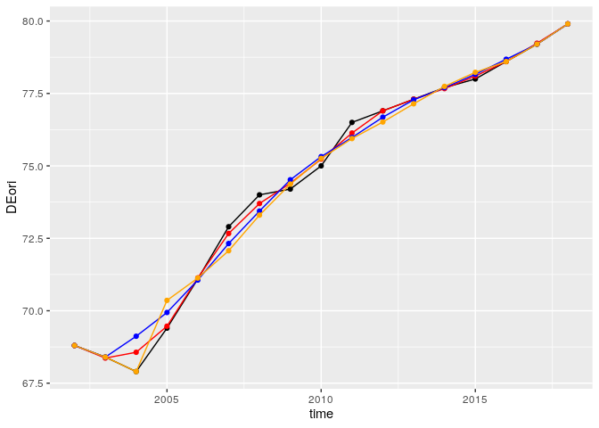

```r
myG <- ggplot(cuTB,aes(x=time,y=DEori))+geom_line()+geom_point()+
       geom_line(aes(x=time,y=DE_k_3),colour="red")+
       geom_point(aes(x=time,y=DE_k_3),colour="red")+
       #
       geom_line(aes(x=time,y=DE_k_5),colour="blue")+
       geom_point(aes(x=time,y=DE_k_5),colour="blue")+
       #
       geom_line(aes(x=time,y=DE_k_7),colour="orange")+
       geom_point(aes(x=time,y=DE_k_7),colour="orange")+
       theme(legend.position = c(.5, .5),
              legend.title = element_text(face = "bold"))

myG
```

The time serie is so short that at $k=7$ a lot of observations are smoothed with different number of observations (shorter at start and end).

The above calulcations are performed by a function in the *convergEU* package:

```r
cuTB <-  emp_20_64_MS[,c("time","IT","DE")]

ma_dataset(cuTB, kappa=3, timeName= "time")
```

```
#> $res
#> # A tibble: 17 x 3
#>     time    IT    DE
#>    <dbl> <dbl> <dbl>
#>  1  2002  59.2  68.8
#>  2  2003  60.3  68.4
#>  3  2004  61.1  68.6
#>  4  2005  61.9  69.5
#>  5  2006  62.2  71.1
#>  6  2007  62.7  72.7
#>  7  2008  62.4  73.7
#>  8  2009  61.8  74.4
#>  9  2010  61.2  75.2
#> 10  2011  61.0  76.1
#> 11  2012  60.5  76.9
#> 12  2013  60.2  77.3
#> 13  2014  60.0  77.7
#> 14  2015  60.7  78.1
#> 15  2016  61.5  78.6
#> 16  2017  62.3  79.2
#> 17  2018  63    79.9
#>
#> $msg
#> NULL
#>
#> $err
#> NULL
```

that is a bit less flexible but it produced standard results.

# 4 Scoreboards

The basis of scoreboard are raw values of an indicator (level, $y_{m,i,t}$) for MS $m$ at time $t$ for indicator $i$. Differences among subsequent years (change) are as well important, namely
$$y_{m,i,t} - y_{m,i,t-1}$$
thus a function to calculate these values may be exploited.

Let’s consider the dataset *emp_20_64_MS*, to calculate such quantities we do the following:

```r
data(emp_20_64_MS)
resTB <- scoreb_yrs(emp_20_64_MS,timeName = "time")
resTB
```

```
#> $res
#> $res$sigma_conv
#> # A tibble: 17 x 9
#>     time stdDev     CV  mean devianceT elle1in elle1su elle2in elle2su
#>    <dbl>  <dbl>  <dbl> <dbl>     <dbl>   <dbl>   <dbl>   <dbl>   <dbl>
#>  1  2002   6.34 0.0939  67.5     1125.    64.3    70.7    61.2    73.9
#>  2  2003   5.95 0.0878  67.8      991.    64.8    70.7    61.8    73.7
#>  3  2004   5.70 0.0839  67.9      909.    65.1    70.8    62.2    73.6
#>  4  2005   5.54 0.0809  68.4      858.    65.7    71.2    62.9    74.0
#>  5  2006   5.57 0.0801  69.6      869.    66.8    72.3    64.0    75.1
#>  6  2007   5.47 0.0775  70.6      838.    67.9    73.3    65.1    76.1
#>  7  2008   5.36 0.0755  71.0      804.    68.3    73.7    65.6    76.3
#>  8  2009   5.03 0.0730  69.0      710.    66.5    71.5    64.0    74.0
#>  9  2010   5.24 0.0769  68.1      768.    65.5    70.7    62.9    73.4
#> 10  2011   5.59 0.0821  68.1      875.    65.3    70.9    62.5    73.7
#> 11  2012   5.98 0.0880  68       1002.    65.0    71.0    62.0    74.0
#> 12  2013   6.28 0.0922  68.0     1103.    64.9    71.2    61.8    74.3
#> 13  2014   5.98 0.0867  69.0     1000.    66.0    72.0    63.0    75.0
#> 14  2015   5.74 0.0820  70.0      922.    67.1    72.9    64.2    75.7
#> 15  2016   5.60 0.0789  71.0      879.    68.2    73.8    65.4    76.6
#> 16  2017   5.37 0.0741  72.5      808.    69.8    75.2    67.1    77.9
#> 17  2018   5.30 0.0717  73.8      786.    71.2    76.5    68.6    79.1
#>
#> $res$sco_level
#> # A tibble: 17 x 29
#>     time    AT    BE    BG    CY    CZ    DE    DK    EE    EL    ES    FI    FR
#>    <dbl> <int> <int> <int> <int> <int> <int> <int> <int> <int> <int> <int> <int>
#>  1  2002     4     3     1     5     4     3     5     3     2     2     4     3
#>  2  2003     4     2     1     5     4     3     5     3     2     2     4     3
#>  3  2004     3     3     1     5     3     3     5     3     2     3     4     3
#>  4  2005     3     3     1     5     3     3     5     4     2     3     4     3
#>  5  2006     3     2     2     5     3     3     5     5     2     3     4     3
#>  6  2007     3     2     3     5     3     3     5     5     2     3     4     3
#>  7  2008     4     2     3     5     3     4     5     5     2     3     4     3
#>  8  2009     4     3     3     5     3     5     5     3     2     2     4     3
#>  9  2010     5     3     2     5     3     5     5     3     2     1     4     3
#> 10  2011     5     3     2     4     4     5     5     3     1     1     5     3
#> 11  2012     5     3     2     3     4     5     5     4     1     1     5     3
#> 12  2013     5     3     2     3     4     5     4     4     1     1     4     3
#> 13  2014     4     3     2     3     4     5     4     4     1     1     4     3
```

[output cut: 49 more lines]

```
#> 13  2014   0.5   0    -0.5   0     0.5   1     0.5   0.5  -1    -1     0.5     0
#> 14  2015   0.5   0    -0.5   0     0.5   1     0.5   1    -1    -1     0.5     0
#> 15  2016   0.5  -0.5  -0.5   0     1     1     0.5   0.5  -1    -1     0       0
#> 16  2017   0.5  -0.5   0     0     1     1     0.5   1    -1    -1     0       0
#> 17  2018   0    -0.5   0     0     1     1     0.5   1    -1    -1     0       0
#> # … with 16 more variables: HR <dbl>, HU <dbl>, IE <dbl>, IT <dbl>, LT <dbl>,
#> #   LU <dbl>, LV <dbl>, MT <dbl>, NL <dbl>, PL <dbl>, PT <dbl>, RO <dbl>,
#> #   SE <dbl>, SI <dbl>, SK <dbl>, UK <dbl>
#>
#>
#> $msg
#> NULL
#>
#> $err
#> NULL
```

where the result is a list of three components: the summary statistics, the numerical labels to indicate the interval of the partition a level belongs to, the interval of the partition a change belongs to.

Numerical labels are assigned as follows (see DRAFT JOINT EMPLOYMENT REPORT FROM THE COMMISSION AND THE COUNCIL):  
* value $-1$ if a the original level or change is $y \leq m -1 \cdot s$;  
* value $-0.5$ if a the original level or change is $m -1\cdot s < y \leq m - 0.5\cdot s$;  
* value $0$ if a the original level or change is $m - 0.5\cdot s< y \leq m +0.5\cdot s$;  
* value $+0.5$ if a the original level or change is $m +0.5\cdot s< y \leq m + 1\cdot s$;  
* value $1$ if a the original level or change is $y > m +1\cdot s$.

We note that there is the possibility of representing the above summaries as coloured plots (TO DO) into scoreboards.

For the comparison of a country with the EU average, the following steps are recommended, from raw data:

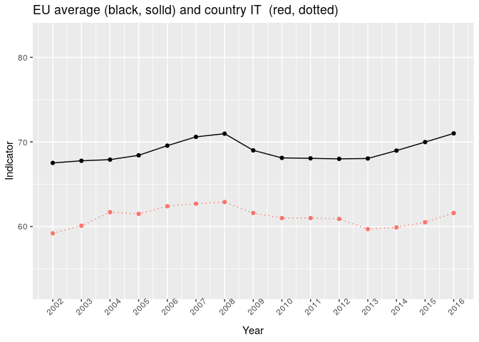

```r
# require(ggplot2)
# data(emp_20_64_MS)
selectedCountry <- "IT"
timeName <-  "time"
myx_angle <-  45

outSig <- sigma_conv(emp_20_64_MS, timeName = timeName,
           time_0=2002,time_t=2016)
miniY <- min(emp_20_64_MS[,- which(names(emp_20_64_MS) == timeName )])
maxiY <-  max(emp_20_64_MS[,- which(names(emp_20_64_MS) == timeName )])
estrattore<-  emp_20_64_MS[,timeName] >= 2002  &  emp_20_64_MS[,timeName] <= 2016
ttmp <- cbind(outSig$res, dplyr::select(emp_20_64_MS[estrattore,], -contains(timeName)))

myG2 <-
  ggplot(ttmp) + ggtitle(
  paste("EU average (black, solid) and country",selectedCountry ," (red, dotted)") )+
  geom_line(aes(x=ttmp[,timeName], y =ttmp[,"mean"]),colour="black") +
  geom_point(aes(x=ttmp[,timeName],y =ttmp[,"mean"]),colour="black") +
#        geom_line()+geom_point()+
    ylim(c(miniY,maxiY)) + xlab("Year") +ylab("Indicator") +
  theme(legend.position = "none")+
  # add countries
  geom_line( aes(x=ttmp[,timeName], y = ttmp[,"IT"],colour="red"),linetype="dotted") +
  geom_point( aes(x=ttmp[,timeName], y = ttmp[,"IT"],colour="red")) +
  ggplot2::scale_x_continuous(breaks = ttmp[,timeName],
                     labels = ttmp[,timeName]) +
   ggplot2::theme(
         axis.text.x=ggplot2::element_text(
         #size = ggplot2::rel(myfont_scale ),
         angle = myx_angle
         #vjust = 1,
         #hjust=1
         ))

myG2
```

It is also possible to graphically show departures in terms of the above defined partition:

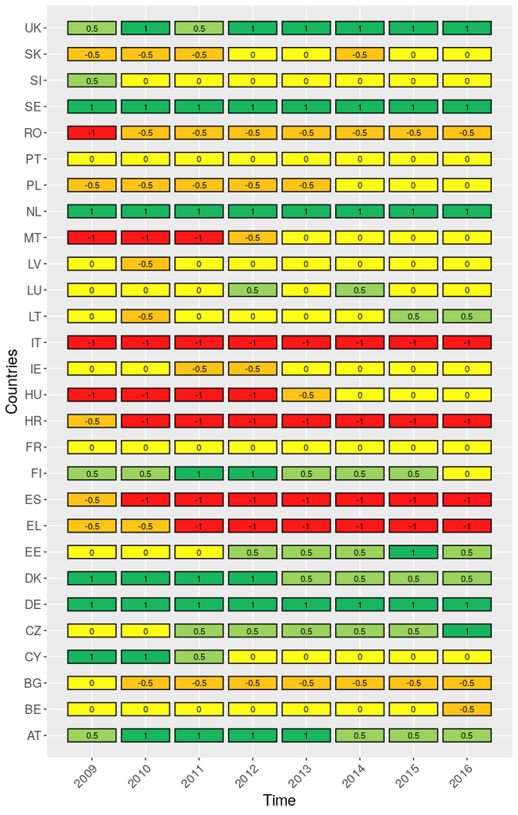

```r
obe_lvl <- scoreb_yrs(emp_20_64_MS,timeName = timeName)$res$sco_level_num
# select subset of time
estrattore <- obe_lvl[,timeName] >= 2009 & obe_lvl[,timeName] <= 2016
scobelvl <- obe_lvl[estrattore,]

my_MSstd <- ms_dynam( scobelvl,
                timeName = "time",
                displace = 0.25,
                displaceh = 0.45,
                dimeFontNum = 3,
                myfont_scale = 1.35,
                x_angle = 45,
                axis_name_y = "Countries",
                axis_name_x = "Time",
                alpha_color = 0.9
                )

my_MSstd
```

# 5 Country fiche

The **counvergEU** package provides a function that automatically prepares one or more country fiches. This function is able to create a directory along an existing path and to copy the rmarkdown file representing the template within it. The rmarkdown file is parameterized so that passing different parameters the compilation takes place with different data, say different indicators and countries.

It is very important to prepare complete data in a tibble (dataset) made by a time variable and as many other variables as countries that enter into the calculation of the time average. Failing to satisfy this requisite causes the use of a wrong mean value at each year. Nevertheless one key country is specified and some other countries of interest may be listed to better decorate graphs and compare performances.

Below, a call to the function *go_ms_fish()* illustrates the syntax:

```r
go_ms_fish(
    workDF ='myTB',
    countryRef ='DE',
    otherCountries = "c('IT','UK','FR')",
    time_0 = 2002,
    time_t = 2016,
    tName = 'time',
    indiType = "highBest",
    aggregation= 'EU27_2020',
    x_angle=  45,
    dataNow=  Sys.time(),
    author = 'A.Student',
    outFile = 'Germany-up2-2016',
    outDir = "/media/fred/STORE/PRJ/2018-TENDER-EU/STEP-1/bitbucketed/tt-fish",
    indiName= 'emp_20_64_MS'
)
```

but it is very important to emphasize some constraints and unusual ways to pass parameters to such a function. In fact, note that the first argument is the working dataset which is passed not as an R object but as a string, the name of the dataset that must be available in the R workspace before invoking *go_ms_fish*.  
The second argument *countryRef* is a string with the short name of a member country that will be shown in one-country plots. Less obvious, argument *indiType = “lowBest”* specifies if the considered indicator is built so that a low value is good for a country or if a high value is good (*indiType = “highBest”*).

Of particular importance the argument *outFile* that can be a string indicating the name of the output file. Similarly *outDir* is the path (unit and folders) in which the final compiled html will be stored. The sintax of the path depend on the operating system; for example *outDir=‘F:/analysis/IT2018’* indicates that in the usb disk called ‘F’, within the folder ‘analysis’ is located folder ‘IT2018’ where R will write the country fiche. Note that a disk called ‘F’ must exist and also folder ‘analysis’ must exist in such unit, while on the contrary folder ‘IT2018’ is created by the function if it does not already exist.

Within the above mentioned output directory, besides the compiled html, it is also stored a file called like specified by *outFile* but with added the string ‘-workspace.RData’ that contains data and plots produced during the compilation of the country fiche for further subsequent use in other technical reports.

# 6 Indicator fiches

An auxiliary function *go_indica_fish()* is provided in the R package *convergEU* to produce an indicator fiches, where the output is an html file. At this purpose, an output directory must be also specifed. Note that some arguments are passed as strings instead of objects, as described in the last section above.

An example of syntax to invoke the procedure is:

```
go_indica_fish(
    time_0 = 2005,
    time_t = 2010,
    timeName = 'time',
    workingDF = 'emp_20_64_MS' ,
    indicaT = 'emp_20_64',
    indiType = c('highBest','lowBest')[1],
    seleMeasure = 'all',
    seleAggre = 'EU27_2020',
    x_angle =  45,
    data_res_download =  FALSE,
    auth = 'A.Student',
    dataNow =  '2019/05/16',
    outFile = "test_IT-emp_20_64_MS",
    outDir = "/media/fred/STORE/PRJ/2018-TENDER-EU/STEP-1/bitbucketed/tt-fish"
  )
```

# 7 References

The following reference may be consulted for details:

- Brussels, 21.11.2018, COM(2018) 761 final, DRAFT JOINT EMPLOYMENT REPORT FROM THE COMMISSION AND THE COUNCIL, accompanying the Communication from the Commission on the Annual Growth Survey 2019.
- Eurofound (2018), Upward convergence in the EU: Concepts, measurements and indicators, Publications Office of the European Union, Luxembourg; by: Massimiliano Mascherini, Martina Bisello, Hans Dubois and Franz Eiffe.
- Tuszynski, J. (2015). **caTools**: Tools: moving window statistics, GIF, Base64, ROC AUC, etc. R package version 1.17.1.2, URL https://CRAN.R-project.org/package=caTools.
- Nedka D. Nikiforova, Federico M. Stefanini, Chiara Litardi, Eleonora Peruffo and Massimiliano Mascherini (2020) Tutorial: analysis of convergence with the convergEU package. Package vignette URL https://local.disia.unifi.it/stefanini/RESEARCH/coneu/tutorial-conv.html

# 8 Appendix: clusters over time of EU MS

In this appendix several lists of member states are defined as follows:

```r
setupConvergEU <- convergEU_glb()
names(setupConvergEU)
```

```
#>  [1] "EUcodes"         "Eurozone"        "EA"              "EU12"
#>  [5] "EU15"            "EU19"            "EU25"            "EU27_2007"
#>  [9] "EU27_2019"       "EU27_2020"       "EU27"            "EU28"
#> [13] "geoRefEUF"       "metaEUStat"      "tmpl_out"        "paralintags"
#> [17] "rounDigits"      "epsilonV"        "scoreBoaTB"      "labels_clusters"
```

and, with more details:

```r
print(setupConvergEU$EUcodes,n=30)
```

```
#> # A tibble: 28 x 4
#>    pae   paeF   paeN paeS
#>    <chr> <chr> <dbl> <chr>
#>  1 1-AT  1-AT      1 AT
#>  2 10-ES 10-ES    10 ES
#>  3 11-FI 11-FI    11 FI
#>  4 12-FR 12-FR    12 FR
#>  5 13-HR 13-HR    13 HR
#>  6 14-HU 14-HU    14 HU
#>  7 15-IE 15-IE    15 IE
#>  8 16-IT 16-IT    16 IT
#>  9 17-LT 17-LT    17 LT
#> 10 18-LU 18-LU    18 LU
#> 11 19-LV 19-LV    19 LV
#> 12 2-BE  2-BE      2 BE
```

[output cut: 16 more lines]

```r
print(setupConvergEU$Eurozone)
```

```
#> $dates
#> [1] NA NA
#>
#> $memberStates
#> # A tibble: 19 x 2
#>    MS          codeMS
#>    <chr>       <chr>
#>  1 Austria     AT
#>  2 Belgium     BE
#>  3 Cyprus      CY
#>  4 Estonia     EE
#>  5 Finland     FI
#>  6 France      FR
#>  7 Germany     DE
#>  8 Greece      EL
#>  9 Ireland     IE
#> 10 Italy       IT
#> 11 Latvia      LV
#> 12 Lithuania   LT
#> 13 Luxembourg  LU
#> 14 Malta       MT
#> 15 Netherlands NL
#> 16 Portugal    PT
#> 17 Slovakia    SK
#> 18 Slovenia    SI
#> 19 Spain       ES
```

```r
setupConvergEU$EU12
```

```
#> $dates
#> [1] "01-11-1993" "31/12/1994"
#>
#> $memberStates
#> # A tibble: 12 x 2
#>    MS             codeMS
#>    <chr>          <chr>
#>  1 Belgium        BE
#>  2 Denmark        DK
#>  3 France         FR
#>  4 Germany        DE
#>  5 Greece         EL
#>  6 Ireland        IE
#>  7 Italy          IT
#>  8 Luxembourg     LU
#>  9 Netherlands    NL
#> 10 Portugal       PT
#> 11 Spain          ES
#> 12 United-Kingdom UK
```

```r
setupConvergEU$EU15
```

```
#> $dates
#> [1] "01-01-1995" "30/04/2004"
#>
#> $memberStates
#> # A tibble: 15 x 2
#>    MS             codeMS
#>    <chr>          <chr>
#>  1 Belgium        BE
#>  2 Denmark        DK
#>  3 France         FR
#>  4 Germany        DE
#>  5 Greece         EL
#>  6 Ireland        IE
#>  7 Italy          IT
#>  8 Luxembourg     LU
#>  9 Netherlands    NL
#> 10 Portugal       PT
#> 11 Spain          ES
#> 12 United-Kingdom UK
#> 13 Austria        AT
#> 14 Finland        FI
#> 15 Sweden         SE
```

```r
print(setupConvergEU$EU25$dates)
```

```
#> [1] "01/05/2004" "31/12/2006"
```

```r
print(setupConvergEU$EU25$memberStates,n=30)
```

```
#> # A tibble: 25 x 2
#>    MS             codeMS
#>    <chr>          <chr>
#>  1 Belgium        BE
#>  2 Denmark        DK
#>  3 France         FR
#>  4 Germany        DE
#>  5 Greece         EL
#>  6 Ireland        IE
#>  7 Italy          IT
#>  8 Luxembourg     LU
#>  9 Netherlands    NL
#> 10 Portugal       PT
#> 11 Spain          ES
#> 12 United-Kingdom UK
#> 13 Austria        AT
#> 14 Finland        FI
#> 15 Sweden         SE
#> 16 Cyprus         CY
#> 17 Czech-Republic CZ
#> 18 Estonia        EE
#> 19 Hungary        HU
#> 20 Latvia         LV
#> 21 Lithuania      LT
#> 22 Malta          MT
#> 23 Poland         PL
#> 24 Slovakia       SK
#> 25 Slovenia       SI
```

```r
print(setupConvergEU$EU27$dates)
```

```
#> [1] "01/02/2020" "00/00/0000"
```

```r
print(setupConvergEU$EU27$memberStates,n=30)
```

```
#> # A tibble: 27 x 2
#>    MS             codeMS
#>    <chr>          <chr>
#>  1 Belgium        BE
#>  2 Denmark        DK
#>  3 France         FR
#>  4 Germany        DE
#>  5 Greece         EL
#>  6 Ireland        IE
#>  7 Italy          IT
#>  8 Luxembourg     LU
#>  9 Netherlands    NL
#> 10 Portugal       PT
#> 11 Spain          ES
#> 12 Austria        AT
#> 13 Finland        FI
#> 14 Sweden         SE
#> 15 Cyprus         CY
#> 16 Czech-Republic CZ
#> 17 Estonia        EE
#> 18 Hungary        HU
#> 19 Latvia         LV
#> 20 Lithuania      LT
#> 21 Malta          MT
#> 22 Poland         PL
#> 23 Slovakia       SK
#> 24 Slovenia       SI
#> 25 Bulgaria       BG
#> 26 Romania        RO
#> 27 Croatia        HR
```

```r
print(setupConvergEU$EU27_2020$dates)
```

```
#> [1] "01/02/2020" "00/00/0000"
```

```r
print(setupConvergEU$EU27_2020$memberStates,n=30)
```

```
#> # A tibble: 27 x 2
#>    MS             codeMS
#>    <chr>          <chr>
#>  1 Belgium        BE
#>  2 Denmark        DK
#>  3 France         FR
#>  4 Germany        DE
#>  5 Greece         EL
#>  6 Ireland        IE
#>  7 Italy          IT
#>  8 Luxembourg     LU
#>  9 Netherlands    NL
#> 10 Portugal       PT
#> 11 Spain          ES
#> 12 Austria        AT
#> 13 Finland        FI
#> 14 Sweden         SE
#> 15 Cyprus         CY
#> 16 Czech-Republic CZ
#> 17 Estonia        EE
#> 18 Hungary        HU
#> 19 Latvia         LV
#> 20 Lithuania      LT
#> 21 Malta          MT
#> 22 Poland         PL
#> 23 Slovakia       SK
#> 24 Slovenia       SI
#> 25 Bulgaria       BG
#> 26 Romania        RO
#> 27 Croatia        HR
```